# Fantasy Football Insights: Unveiling the NFL's Data Playbook

## Dataset

https://github.com/nflverse/nflverse-data/releases?page=2

## Questions:

- What QBs had the best performances in 2023? How would their averages simulate in another season?
- What WRs had the best performances in 2023? How would their averages simulate in another season?
- What RBs had the best performances in 2023? How would their averages simulate in another season?
- What positions are the best to draft in fantasy football based on simulated averages?

## Abstract

Fantasy football enthusiasts rely on data-driven insights to make strategic decisions when drafting players for their teams. In this project, we aim to develop a simulator for fantasy football performance based on the statistical performances of quarterbacks (QBs), wide receivers (WRs), and running backs (RBs) during the 2023 season. By analyzing the best-performing QBs, WRs, and RBs from the 2023 season, we will assess how their averages could simulate in another season.

First, we will identify the QBs, WRs, and RBs who had the best performances in 2023, considering various metrics such as passing yards, passing touchdowns, receptions, rushing yards, and rushing touchdowns. Using these players' statistical averages, we will develop a simulation model to predict their performances in another season. By applying statistical methods and machine learning techniques, we will estimate the potential outcomes for each player in a simulated scenario.

Next, we will evaluate the simulated averages for QBs, WRs, and RBs to determine which positions offer the most consistent and high-scoring performances in fantasy football. By comparing the simulated averages across different positions, we will identify the positions that are optimal for drafting in fantasy football leagues.

Overall, this project will provide valuable insights into the performances of QBs, WRs, and RBs in fantasy football, enabling fantasy football enthusiasts to make informed decisions when drafting players for their teams.

## Tools and Libraries:

The project will be done in Python using Google Colaboratory. This gives a user-friendly workspace, with many tools at my disposal to analyze the dataset. Pandas, NumPy, Tabulate, Matplotlib, and Seaborn will be the main libraries used to conduct the data analysis and display the visualization of the data.

```python
import pandas as pd
from tabulate import tabulate
import matplotlib.pyplot as plt
import numpy as np
import seaborn as sns


player_stats = pd.read_csv("http://136.183.56.193/MAT366S24/final/player_stats_2023.csv")
defense_grades = pd.read_csv("http://136.183.56.193/MAT366S24/final/defense_grades.csv")
```

# Question 1:

## Part 1: What QBs had the best performances in 2023?

Step 1: Get the totals for every QB in the dataset.

```python
# Filter data for QB position
qb_stats = player_stats[player_stats['position_group'] == 'QB']

# Check if there are quarterbacks in the dataset
if qb_stats.empty:
    print("No quarterbacks found in the dataset.")
else:
    # Select relevant columns for QB statistics
    relevant_stats_columns = ['player_name', 'completions', 'attempts', 'passing_yards', 'passing_tds', 'interceptions', 'passing_epa', 'rushing_yards', 'rushing_tds', 'fantasy_points', 'fantasy_points_ppr']

    # Group data by player name and sum up the statistics for each player
    qb_totals = qb_stats.groupby('player_name')[relevant_stats_columns[1:]].sum().reset_index()

    # Display the total statistics for each QB
    print("Total statistics for QB position by player for the 2023 season:")
    print(tabulate(qb_totals, headers='keys', tablefmt='pretty'))
```

```
Total statistics for QB position by player for the 2023 season:
+----+---------------------+-------------+----------+---------------+-------------+---------------+----------------------+---------------+-------------+--------------------+--------------------+
|    |     player_name     | completions | attempts | passing_yards | passing_tds | interceptions |     passing_epa      | rushing_yards | rushing_tds |   fantasy_points   | fantasy_points_ppr |
+----+---------------------+-------------+----------+---------------+-------------+---------------+----------------------+---------------+-------------+--------------------+--------------------+
| 0  |      A.Dalton       |     34      |    58    |      361      |      2      |       0       |   4.54832959122722   |      12       |      0      |       23.64        |       23.64        |
| 1  |     A.McCarron      |      4      |    5     |      19       |      0      |       0       |  -5.25107204460073   |       0       |      0      |        0.76        |        0.76        |
| 2  |     A.O'Connell     |     213     |   343    |     2218      |     12      |       7       | -16.852607789448367  |      11       |      1      |       125.82       |       125.82       |
| 3  |    A.Richardson     |     50      |    84    |      577      |      3      |       1       |  4.587791287072109   |      136      |      4      |       72.68        |       72.68        |
| 4  |      A.Rodgers      |      0      |    1     |       0       |      0      |       0       |  -2.03195988433436   |       0       |      0      |        0.0         |        0.0         |
| 5  |      B.Gabbert      |     18      |    35    |      185      |      0      |       3       |  -16.14328710516377  |      45       |      0      |        5.9         |        5.9         |
| 6  |       B.Hoyer       |     23      |    42    |      231      |      0      |       2       |  -8.78077275336437   |      -3       |      0      | 4.9399999999999995 | 4.9399999999999995 |
| 7  |     B.Mayfield      |     412     |   643    |     4730      |     34      |      12       |  67.00060209138448   |      194      |      1      |       324.6        |       324.6        |
| 8  |       B.Purdy       |     374     |   552    |     5054      |     34      |      12       |  163.7380453775758   |      218      |      2      |       343.96       |       343.96       |
| 9  |      B.Rypien       |     18      |    38    |      172      |      0      |       1       |  -19.72529150741341  |      19       |      0      | 6.779999999999999  | 6.779999999999999  |
| 10 |       B.Young       |     315     |   527    |     2877      |     11      |      10       |  -160.3264418747372  |      253      |      0      |       156.38       |       156.38       |
| 11 |       B.Zappe       |     127     |   212    |     1272      |      6      |       9       |  -81.79545271547403  |      83       |      1      |       69.18        |       69.18        |
| 12 |     C.Beathard      |     40      |    53    |      349      |      1      |       0       |  5.580714992024473   |      35       |      0      |       21.46        |       21.46        |
| 13 |      C.Keenum       |     34      |    53    |      291      |      1      |       3       |  -20.65132938160178  |       1       |      0      |        9.74        |        9.74        |
| 14 |       C.Rush        |     18      |    24    |      144      |      0      |       1       |  -5.239947747569218  |      -5       |      0      |        3.26        |        3.26        |
| 15 |      C.Stroud       |     354     |   553    |     4557      |     26      |       5       |  74.97264220208687   |      167      |      3      |       304.98       |       305.98       |
| 16 |       C.Tune        |     12      |    21    |      62       |      0      |       2       | -34.749543172656544  |      30       |      1      | 7.4799999999999995 | 7.4799999999999995 |
| 17 |       C.Wentz       |     17      |    24    |      163      |      2      |       1       |   7.06485306221293   |      56       |      1      |       26.12        |       26.12        |
| 18 |       D.Carr        |     375     |   548    |     3878      |     25      |       8       |  25.919057313621636  |      40       |      0      |       241.12       |       241.12       |
| 19 |       D.Jones       |     108     |   160    |      909      |      2      |       6       | -60.455004205716875  |      206      |      1      |       56.96        |       56.96        |
| 20 |       D.Lock        |     48      |    76    |      543      |      3      |       3       | -0.6537227910978451  |      14       |      0      | 29.119999999999997 | 29.119999999999997 |
| 21 |       D.Mills       |     19      |    40    |      179      |      2      |       0       |  -6.21241955182632   |       5       |      0      |       17.66        |       17.66        |
```

[output cut: 62 more lines]

Step 2: Refine this list to only take the best QB from each of the 32 teams.

```python
# Filter data for QB position
qb_stats = player_stats[player_stats['position_group'] == 'QB']

# Check if there are quarterbacks in the dataset
if qb_stats.empty:
    print("No quarterbacks found in the dataset.")
else:
    # Select relevant columns for QB statistics
    relevant_stats_columns = ['player_name', 'completions', 'attempts', 'passing_yards', 'passing_tds', 'interceptions', 'passing_epa', 'rushing_yards', 'rushing_tds', 'fantasy_points', 'fantasy_points_ppr']

    # Group data by player name and sum up the statistics for each player
    qb_totals = qb_stats.groupby(['player_name', 'recent_team'])[relevant_stats_columns[1:]].sum().reset_index()

    # Get the best QB from each team
    best_qb_per_team = qb_totals.sort_values(by='fantasy_points', ascending=False).groupby('recent_team').first().reset_index()

    # Display the best QB from each team
    print("Best quarterback from each team:")
    print(tabulate(best_qb_per_team, headers='keys', tablefmt='pretty'))
```

```
Best quarterback from each team:
+----+-------------+--------------+-------------+----------+---------------+-------------+---------------+---------------------+---------------+-------------+--------------------+--------------------+
|    | recent_team | player_name  | completions | attempts | passing_yards | passing_tds | interceptions |     passing_epa     | rushing_yards | rushing_tds |   fantasy_points   | fantasy_points_ppr |
+----+-------------+--------------+-------------+----------+---------------+-------------+---------------+---------------------+---------------+-------------+--------------------+--------------------+
| 0  |     ARI     |   K.Murray   |     176     |   268    |     1799      |     10      |       5       | -12.878469075476168 |      244      |      3      |       146.36       |       146.36       |
| 1  |     ATL     |   D.Ridder   |     249     |   388    |     2836      |     12      |      12       | -33.399741175844255 |      193      |      5      |       180.14       |       181.14       |
| 2  |     BAL     |  L.Jackson   |     343     |   516    |     4102      |     27      |       8       |  56.88690344634787  |      975      |      7      |       384.88       |       385.88       |
| 3  |     BUF     |   J.Allen    |     432     |   648    |     4695      |     33      |      18       | 100.00074853776603  |      670      |     18      |       458.8        |       458.8        |
| 4  |     CAR     |   B.Young    |     315     |   527    |     2877      |     11      |      10       | -160.3264418747372  |      253      |      0      |       156.38       |       156.38       |
| 5  |     CHI     |   J.Fields   |     227     |   370    |     2562      |     16      |       9       | -36.296476713845955 |      657      |      4      | 230.17999999999998 | 230.17999999999998 |
| 6  |     CIN     |   J.Burrow   |     244     |   365    |     2309      |     15      |       6       |  6.095037059046869  |      88       |      0      |       147.16       |       147.16       |
| 7  |     CLE     |   J.Flacco   |     157     |   250    |     1923      |     14      |      10       | -19.36687926605717  |      15       |      0      |       114.42       |       114.42       |
| 8  |     DAL     |  D.Prescott  |     451     |   650    |     4919      |     39      |      11       | 115.31946169444555  |      287      |      2      |       373.46       |       373.46       |
| 9  |     DEN     |   R.Wilson   |     297     |   447    |     3070      |     26      |       8       | -16.33619752416893  |      341      |      3      |       256.9        |       256.9        |
| 10 |     DET     |    J.Goff    |     484     |   716    |     5412      |     34      |      12       | 108.00487175719736  |      24       |      2      |       338.88       |       338.88       |
| 11 |     GB      |    J.Love    |     409     |   634    |     4625      |     37      |      13       | 108.66983910613105  |      249      |      4      | 355.90000000000003 | 355.90000000000003 |
| 12 |     HOU     |   C.Stroud   |     354     |   553    |     4557      |     26      |       5       |  74.97264220208687  |      167      |      3      |       304.98       |       305.98       |
| 13 |     IND     |  G.Minshew   |     305     |   490    |     3305      |     15      |       9       |  -5.7517065536534   |      100      |      3      | 196.20000000000002 | 196.20000000000002 |
| 14 |     JAX     |  T.Lawrence  |     370     |   564    |     4016      |     21      |      14       | 0.7773138562676829  |      339      |      4      |       262.54       |       262.54       |
| 15 |     KC      |  P.Mahomes   |     505     |   746    |     5234      |     33      |      15       |  86.93810603804353  |      530      |      0      |       358.36       |       358.36       |
| 16 |     LA      |  M.Stafford  |     351     |   557    |     4332      |     26      |      11       |  73.60816255160817  |      65       |      0      |       265.78       |       265.78       |
| 17 |     LAC     |  J.Herbert   |     297     |   456    |     3134      |     20      |       7       |  26.8638555228565   |      228      |      3      |       233.16       |       234.16       |
| 18 |     LV      | A.O'Connell  |     213     |   343    |     2218      |     12      |       7       | -16.852607789448367 |      11       |      1      |       125.82       |       125.82       |
| 19 |     MIA     | T.Tagovailoa |     408     |   599    |     4823      |     30      |      15       | 109.62352037596902  |      99       |      0      |       284.82       |       284.82       |
```

[output cut: 13 more lines]

Step 3: Graph the stats to visualize the best performers

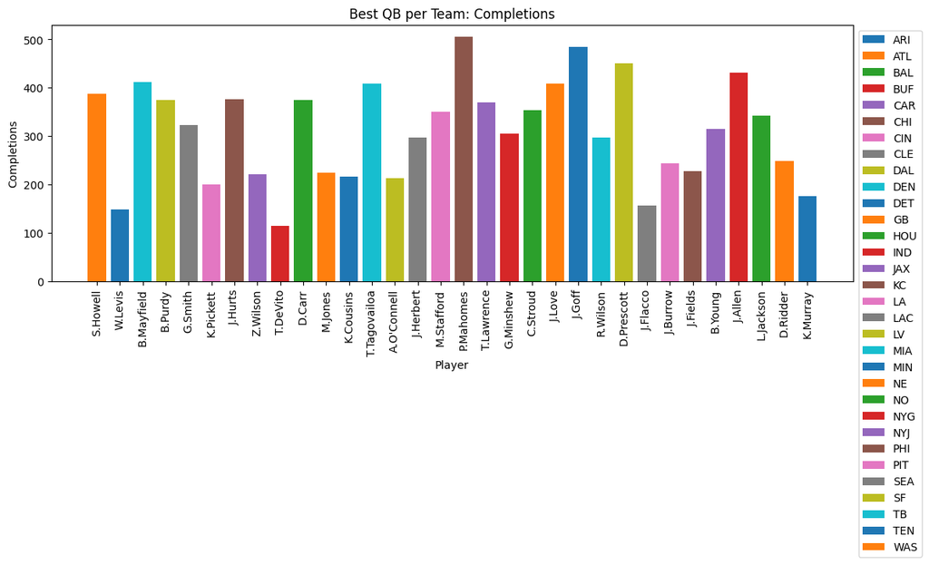

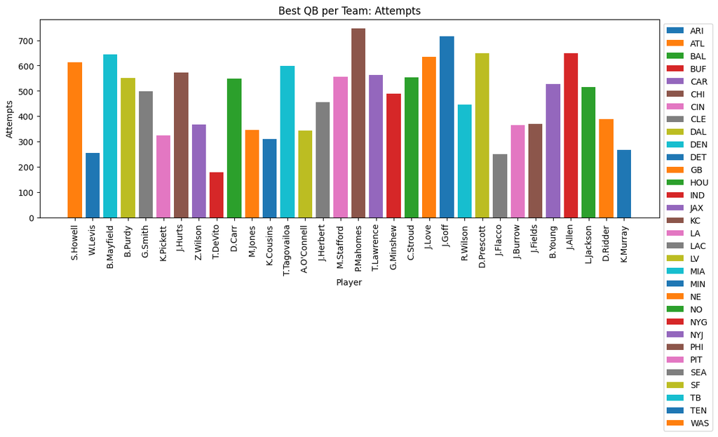

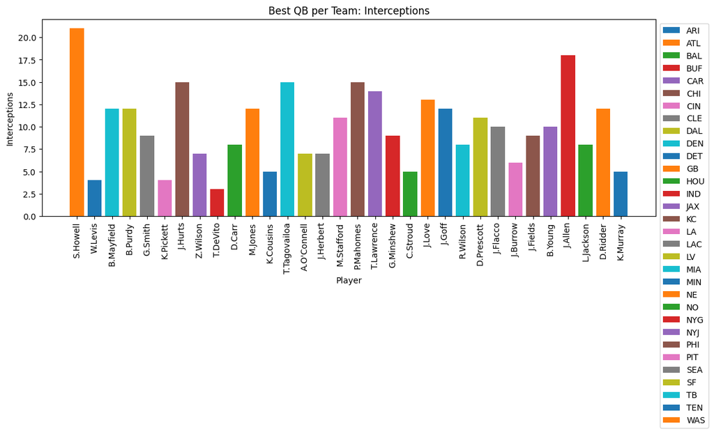

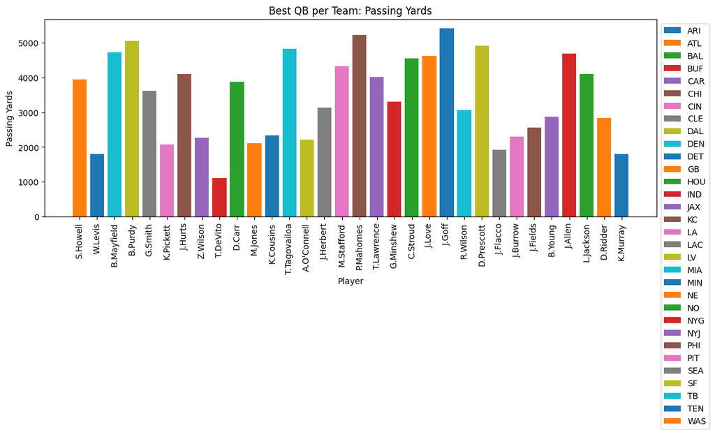

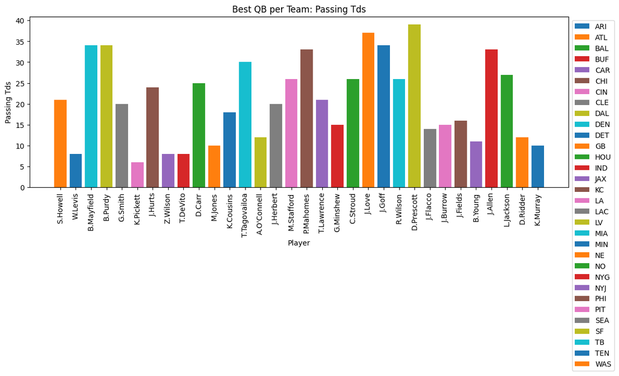

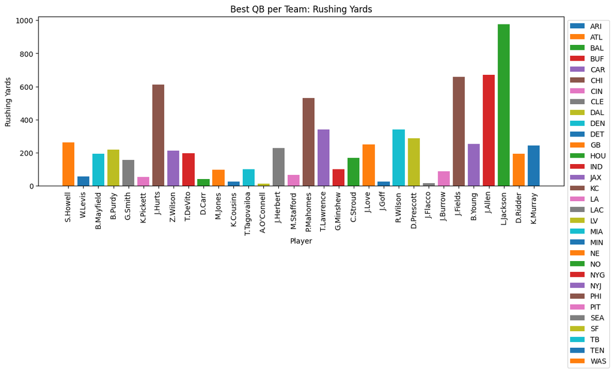

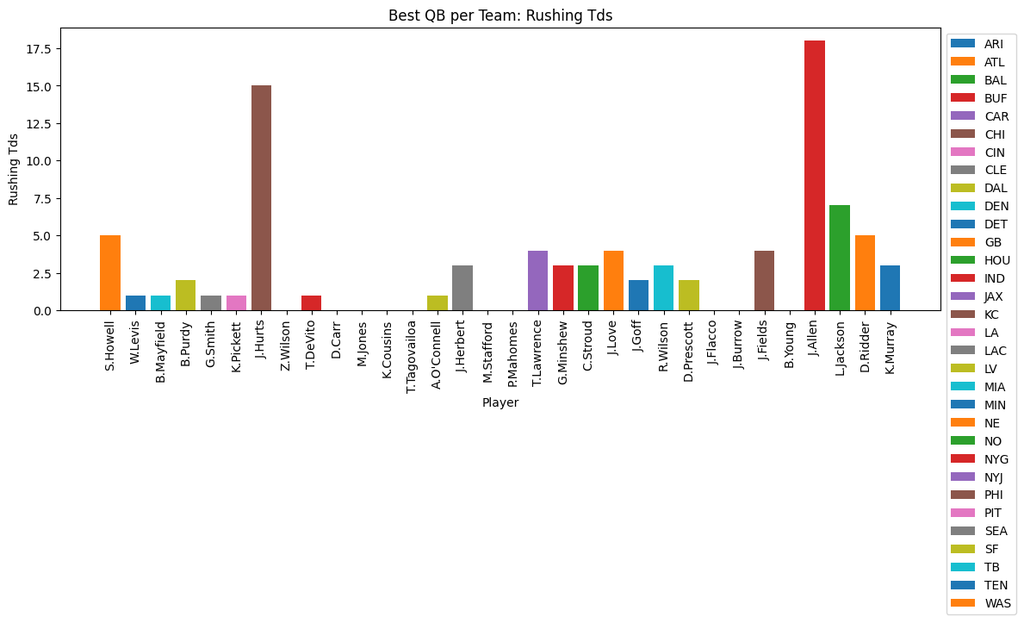

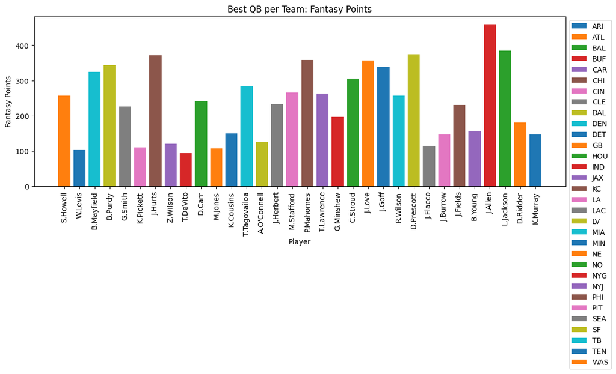

```python
# Filter data for QB position
qb_stats = player_stats[player_stats['position_group'] == 'QB']

# Check if there are quarterbacks in the dataset
if qb_stats.empty:
    print("No quarterbacks found in the dataset.")
else:
    # Select relevant columns for QB statistics
    relevant_stats_columns = ['player_name', 'recent_team', 'completions', 'attempts', 'interceptions', 'passing_yards', 'passing_tds', 'rushing_yards', 'rushing_tds', 'fantasy_points', 'fantasy_points_ppr']

    # Group data by player name and sum up the statistics for each player
    qb_totals = qb_stats.groupby(['player_name', 'recent_team'])[relevant_stats_columns[2:]].sum().reset_index()

    # Get the best QB from each team
    best_qb_per_team = qb_totals.sort_values(by='fantasy_points', ascending=False).groupby('recent_team').head(1)

    # Create separate plots for completions, attempts, interceptions, passing yards, passing touchdowns, rushing yards, rushing touchdowns, and fantasy points
    for stat in ['completions', 'attempts', 'interceptions', 'passing_yards', 'passing_tds', 'rushing_yards', 'rushing_tds', 'fantasy_points']:
        # Create a new figure
        plt.figure(figsize=(12, 6))

        # Iterate over each team and plot the data for the best QB
        for team, group in best_qb_per_team.groupby('recent_team'):
            plt.bar(group['player_name'], group[stat], label=team)

        # Set plot title and labels
        plt.title(f'Best QB per Team: {stat.replace("_", " ").title()}')
        plt.xlabel('Player')
        plt.ylabel(stat.replace("_", " ").title())
        plt.xticks(rotation=90, ha='center')  # Rotate x-axis labels vertically
        plt.gca().invert_xaxis()  # Invert x-axis to display player names vertically

        # Add legend outside the plot
        plt.legend(loc='upper left', bbox_to_anchor=(1, 1))

        # Show plot
        plt.tight_layout()
        plt.show()
```

Step 4: Display a list of the 5 best fantasy performing QBs

```python
# Filter data for QB position
qb_stats = player_stats[player_stats['position_group'] == 'QB']

# Check if there are quarterbacks in the dataset
if qb_stats.empty:
    print("No quarterbacks found in the dataset.")
else:
    # Select relevant columns for QB statistics
    relevant_stats_columns = ['player_name', 'completions', 'attempts', 'passing_yards', 'passing_tds', 'interceptions', 'passing_epa', 'fantasy_points', 'fantasy_points_ppr']

    # Group data by player name and sum up the statistics for each player
    qb_totals = qb_stats.groupby(['player_name', 'recent_team'])[relevant_stats_columns[1:]].sum().reset_index()

    # Get the best QB from each team
    best_qb_per_team = qb_totals.sort_values(by='fantasy_points', ascending=False).groupby('recent_team').first().reset_index()

    # Rank the top 5 quarterbacks by fantasy points
    top_5_qbs = qb_totals.sort_values(by='fantasy_points', ascending=False).head(5)

    # Display the top 5 quarterbacks
    print("Top 5 quarterbacks by fantasy points:")
    print(top_5_qbs[['player_name', 'fantasy_points']])
```

```
Top 5 quarterbacks by fantasy points:
   player_name  fantasy_points
29     J.Allen          458.80
51   L.Jackson          384.88
22  D.Prescott          373.46
42     J.Hurts          371.32
64   P.Mahomes          358.36
```

## Part 2: How would their averages simulate in another season?

Step 5: Get the averages of the starting QBs and save them to a csv to run a simulation

```python
# Filter data for QB position
qb_stats = player_stats[player_stats['position_group'] == 'QB']

# Check if there are quarterbacks in the dataset
if qb_stats.empty:
    print("No quarterbacks found in the dataset.")
else:
    # Define the list of desired players
    desired_players = ['K.Murray', 'D.Ridder', 'L.Jackson', 'J.Allen', 'B.Young', 'J.Fields', 'J.Burrow', 'J.Flacco',
                       'D.Prescott', 'R.Wilson', 'J.Goff', 'J.Love', 'C.Stroud', 'G.Minshew', 'T.Lawrence', 'P.Mahomes',
                       'M.Stafford', 'J.Herbert', "A.O'Connell", 'T.Tagovailoa', 'K.Cousins', 'M.Jones', 'D.Carr', 'T.DeVito',
                       'Z.Wilson', 'J.Hurts', 'K.Pickett', 'G.Smith', 'B.Purdy', 'B.Mayfield', 'W.Levis', 'S.Howell']

    # Filter out players not in the desired list
    qb_stats = qb_stats[qb_stats['player_name'].isin(desired_players)]

    # Select relevant columns for QB statistics
    relevant_stats_columns = ['player_name', 'completions', 'attempts', 'passing_yards', 'passing_tds',
                              'interceptions', 'passing_epa', 'fantasy_points', 'fantasy_points_ppr',
                              'recent_team', 'rushing_yards', 'rushing_tds']

    # Group data by player name and find the best QB for each player
    best_qb_per_player = qb_stats.groupby('player_name').apply(lambda x: x.nlargest(1, 'fantasy_points')).reset_index(drop=True)

    # Calculate the average statistics for each player's best QB
    avg_stats_per_player = best_qb_per_player.groupby('player_name')[relevant_stats_columns[1:]].apply(lambda x: x.mean(numeric_only=True))

    # Save the average statistics to a CSV file
    avg_stats_per_player.to_csv("average_stats_per_QB.csv")

    print("CSV file 'average_stats_per_QB.csv' has been saved successfully.")
```

```
CSV file 'average_stats_per_QB.csv' has been saved successfully.
```

Step 6: Run a simulation.

This is a rough simulation of how the players will perform agisnst all 32 teams. Every team has a grade based on how their defense performed last year.

```python
# Load average stats for each starting QB
avg_stats_per_qb = pd.read_csv("average_stats_per_QB.csv")

# Create an empty list to store DataFrames of predicted stats
predicted_stats_list = []

# Define mean and standard deviation for random variations
mean_variation = 0  # Mean of the variation (no change from base prediction)
std_deviation = 5   # Standard deviation for randomness

# Iterate over each starting QB
for _, qb_row in avg_stats_per_qb.iterrows():
    player_name = qb_row["player_name"]

    # Create a list to store predicted stats for the current QB
    qb_predicted_stats = []

    # Iterate over each team
    for _, team_row in defense_grades.iterrows():
        team_name = team_row["team_name"]
        defense_grade = team_row["grade"]

        # Calculate predicted stats based on QB's average stats and defense grade
        # Introduce randomness using normal distribution
        completions_variation = np.random.normal(mean_variation, std_deviation)
        attempts_variation = np.random.normal(mean_variation, std_deviation)
        passing_yards_variation = np.random.normal(mean_variation, std_deviation)
        passing_tds_variation = np.random.normal(mean_variation, std_deviation)
        rushing_yards_variation = np.random.normal(mean_variation, std_deviation)
        rushing_tds_variation = np.random.normal(mean_variation, std_deviation)

        predicted_completions = qb_row["completions"] * (32 - defense_grade) / 32 * (1 + completions_variation/100)
        predicted_attempts = qb_row["attempts"] * (32 - defense_grade) / 32 * (1 + attempts_variation/100)
        predicted_passing_yards = qb_row["passing_yards"] * (32 - defense_grade) / 32 * (1 + passing_yards_variation/100)
        predicted_passing_tds = qb_row["passing_tds"] * (32 - defense_grade) / 32 * (1 + passing_tds_variation/100)
        predicted_rushing_yards = qb_row["rushing_yards"] * (32 - defense_grade) / 32 * (1 + rushing_yards_variation/100)
        predicted_rushing_tds = qb_row["rushing_tds"] * (32 - defense_grade) / 32 * (1 + rushing_tds_variation/100)

        # Append the predicted stats to the list
        qb_predicted_stats.append({
            "player_name": player_name,
            "team_name": team_name,
            "predicted_completions": predicted_completions,
            "predicted_attempts": predicted_attempts,
            "predicted_passing_yards": predicted_passing_yards,
            "predicted_passing_tds": predicted_passing_tds,
            "predicted_rushing_yards": predicted_rushing_yards,
            "predicted_rushing_tds": predicted_rushing_tds
        })

    # Convert the list of dictionaries to a DataFrame
    qb_predicted_stats_df = pd.DataFrame(qb_predicted_stats)

    # Append the DataFrame for the current QB to the list
    predicted_stats_list.append(qb_predicted_stats_df)

# Concatenate all DataFrames in the list into a single DataFrame
predicted_stats = pd.concat(predicted_stats_list)

# Save the predicted stats to a CSV file
predicted_stats.to_csv("predicted_QB_stats.csv", index=False)

print("Simulation completed. Predicted stats saved to 'predicted_QB_stats.csv'.")
```

```
Simulation completed. Predicted stats saved to 'predicted_QB_stats.csv'.
```

Step 7: Calculate the mean of every game. This value will give us a rough estimate of the mean performence.

```python
# Read the CSV file into a DataFrame
df = pd.read_csv("predicted_QB_stats.csv")

# Convert relevant columns to numeric types
numeric_cols = ['predicted_completions', 'predicted_attempts', 'predicted_passing_yards', 'predicted_passing_tds', 'predicted_rushing_yards', 'predicted_rushing_tds']
df[numeric_cols] = df[numeric_cols].apply(pd.to_numeric, errors='coerce')

# Filter out rows with non-numeric values in the numeric columns
df = df.dropna(subset=numeric_cols)

# Group by player_name and calculate the mean for each player's statistics
df_mean = df.groupby('player_name')[numeric_cols].mean()

# Reset index to make player_name a column again
df_mean.reset_index(inplace=True)

# Display the resulting DataFrame
print(tabulate(df_mean, headers='keys', tablefmt='fancy_grid'))

# Save the resulting DataFrame to a CSV file
df_mean.to_csv("mean_predicted_QB_stats.csv", index=False)
```

```
╒════╤═══════════════╤═════════════════════════╤══════════════════════╤═══════════════════════════╤═════════════════════════╤═══════════════════════════╤═════════════════════════╕
│    │ player_name   │   predicted_completions │   predicted_attempts │   predicted_passing_yards │   predicted_passing_tds │   predicted_rushing_yards │   predicted_rushing_tds │
╞════╪═══════════════╪═════════════════════════╪══════════════════════╪═══════════════════════════╪═════════════════════════╪═══════════════════════════╪═════════════════════════╡
│  0 │ A.O'Connell   │                 9.75752 │              16.4904 │                  121.027  │                1.93143  │                  0        │                0        │
├────┼───────────────┼─────────────────────────┼──────────────────────┼───────────────────────────┼─────────────────────────┼───────────────────────────┼─────────────────────────┤
│  1 │ B.Mayfield    │                10.5877  │              13.6915 │                  183.734  │                1.94008  │                 -0.980227 │                0        │
├────┼───────────────┼─────────────────────────┼──────────────────────┼───────────────────────────┼─────────────────────────┼───────────────────────────┼─────────────────────────┤
│  2 │ B.Purdy       │                 9.16343 │              13.2167 │                  152.055  │                1.90314  │                  4.31942  │                0        │
├────┼───────────────┼─────────────────────────┼──────────────────────┼───────────────────────────┼─────────────────────────┼───────────────────────────┼─────────────────────────┤
│  3 │ B.Young       │                10.9679  │              17.6469 │                  151.672  │                0.967575 │                  8.3277   │                0        │
├────┼───────────────┼─────────────────────────┼──────────────────────┼───────────────────────────┼─────────────────────────┼───────────────────────────┼─────────────────────────┤
│  4 │ C.Stroud      │                14.4838  │              20.4663 │                  227.435  │                2.43146  │                  0        │                0        │
├────┼───────────────┼─────────────────────────┼──────────────────────┼───────────────────────────┼─────────────────────────┼───────────────────────────┼─────────────────────────┤
│  5 │ D.Carr        │                10.4981  │              13.2755 │                  126.428  │                1.96953  │                  2.95589  │                0        │
├────┼───────────────┼─────────────────────────┼──────────────────────┼───────────────────────────┼─────────────────────────┼───────────────────────────┼─────────────────────────┤
│  6 │ D.Prescott    │                12.5666  │              16.8903 │                  194.838  │                1.94439  │                  8.20002  │                0.487169 │
├────┼───────────────┼─────────────────────────┼──────────────────────┼───────────────────────────┼─────────────────────────┼───────────────────────────┼─────────────────────────┤
│  7 │ D.Ridder      │                13.6181  │              17.6458 │                  160.384  │                0.49399  │                  4.79351  │                0.486647 │
├────┼───────────────┼─────────────────────────┼──────────────────────┼───────────────────────────┼─────────────────────────┼───────────────────────────┼─────────────────────────┤
│  8 │ G.Minshew     │                 7.3651  │              11.1398 │                  149.098  │                0.9651   │                 13.9372   │                0.972995 │
├────┼───────────────┼─────────────────────────┼──────────────────────┼───────────────────────────┼─────────────────────────┼───────────────────────────┼─────────────────────────┤
│  9 │ G.Smith       │                11.0472  │              19.912  │                  162.275  │                1.45489  │                  2.91774  │                0.48638  │
├────┼───────────────┼─────────────────────────┼──────────────────────┼───────────────────────────┼─────────────────────────┼───────────────────────────┼─────────────────────────┤
│ 10 │ J.Allen       │                14.368   │              24.2825 │                  165.519  │                0.972405 │                 39.3191   │                0.964486 │
├────┼───────────────┼─────────────────────────┼──────────────────────┼───────────────────────────┼─────────────────────────┼───────────────────────────┼─────────────────────────┤
│ 11 │ J.Burrow      │                13.52    │              15.7813 │                  135.705  │                1.44547  │                 20.8927   │                0        │
```

[output cut: 41 more lines]

Step 8: Display the fantasy points based on the mean results from the simulation.

```python
# Read the CSV file into a DataFrame
df = pd.read_csv("mean_predicted_QB_stats.csv")

# Define the multipliers for fantasy points
passing_yards_multiplier = 0.04
passing_tds_multiplier = 4
rushing_yards_multiplier = 0.1
rushing_tds_multiplier = 6

# Calculate fantasy points for passing yards, passing touchdowns, rushing yards, and rushing touchdowns
df['fantasy_points_passing_yards'] = df['predicted_passing_yards'] * passing_yards_multiplier
df['fantasy_points_passing_tds'] = df['predicted_passing_tds'] * passing_tds_multiplier
df['fantasy_points_rushing_yards'] = df['predicted_rushing_yards'] * rushing_yards_multiplier
df['fantasy_points_rushing_tds'] = df['predicted_rushing_tds'] * rushing_tds_multiplier

# Calculate total fantasy points
df['total_fantasy_points'] = (df['fantasy_points_passing_yards'] + df['fantasy_points_passing_tds'] +
                              df['fantasy_points_rushing_yards'] + df['fantasy_points_rushing_tds'])

# Select only the specified columns
df_selected = df[['player_name', 'fantasy_points_passing_yards', 'fantasy_points_passing_tds',
                  'fantasy_points_rushing_yards', 'fantasy_points_rushing_tds', 'total_fantasy_points']]

# Display the selected DataFrame
print(tabulate(df_selected, headers='keys', tablefmt='fancy_grid'))
```

```
╒════╤═══════════════╤════════════════════════════════╤══════════════════════════════╤════════════════════════════════╤══════════════════════════════╤════════════════════════╕
│    │ player_name   │   fantasy_points_passing_yards │   fantasy_points_passing_tds │   fantasy_points_rushing_yards │   fantasy_points_rushing_tds │   total_fantasy_points │
╞════╪═══════════════╪════════════════════════════════╪══════════════════════════════╪════════════════════════════════╪══════════════════════════════╪════════════════════════╡
│  0 │ A.O'Connell   │                        4.84109 │                      7.7257  │                      0         │                      0       │               12.5668  │
├────┼───────────────┼────────────────────────────────┼──────────────────────────────┼────────────────────────────────┼──────────────────────────────┼────────────────────────┤
│  1 │ B.Mayfield    │                        7.34935 │                      7.76033 │                     -0.0980227 │                      0       │               15.0117  │
├────┼───────────────┼────────────────────────────────┼──────────────────────────────┼────────────────────────────────┼──────────────────────────────┼────────────────────────┤
│  2 │ B.Purdy       │                        6.08221 │                      7.61255 │                      0.431942  │                      0       │               14.1267  │
├────┼───────────────┼────────────────────────────────┼──────────────────────────────┼────────────────────────────────┼──────────────────────────────┼────────────────────────┤
│  3 │ B.Young       │                        6.06687 │                      3.8703  │                      0.83277   │                      0       │               10.7699  │
├────┼───────────────┼────────────────────────────────┼──────────────────────────────┼────────────────────────────────┼──────────────────────────────┼────────────────────────┤
│  4 │ C.Stroud      │                        9.0974  │                      9.72582 │                      0         │                      0       │               18.8232  │
├────┼───────────────┼────────────────────────────────┼──────────────────────────────┼────────────────────────────────┼──────────────────────────────┼────────────────────────┤
│  5 │ D.Carr        │                        5.05711 │                      7.87813 │                      0.295589  │                      0       │               13.2308  │
├────┼───────────────┼────────────────────────────────┼──────────────────────────────┼────────────────────────────────┼──────────────────────────────┼────────────────────────┤
│  6 │ D.Prescott    │                        7.7935  │                      7.77756 │                      0.820002  │                      2.92301 │               19.3141  │
├────┼───────────────┼────────────────────────────────┼──────────────────────────────┼────────────────────────────────┼──────────────────────────────┼────────────────────────┤
│  7 │ D.Ridder      │                        6.41537 │                      1.97596 │                      0.479351  │                      2.91988 │               11.7906  │
├────┼───────────────┼────────────────────────────────┼──────────────────────────────┼────────────────────────────────┼──────────────────────────────┼────────────────────────┤
│  8 │ G.Minshew     │                        5.96392 │                      3.8604  │                      1.39372   │                      5.83797 │               17.056   │
├────┼───────────────┼────────────────────────────────┼──────────────────────────────┼────────────────────────────────┼──────────────────────────────┼────────────────────────┤
│  9 │ G.Smith       │                        6.49099 │                      5.81956 │                      0.291774  │                      2.91828 │               15.5206  │
├────┼───────────────┼────────────────────────────────┼──────────────────────────────┼────────────────────────────────┼──────────────────────────────┼────────────────────────┤
│ 10 │ J.Allen       │                        6.62076 │                      3.88962 │                      3.93191   │                      5.78692 │               20.2292  │
├────┼───────────────┼────────────────────────────────┼──────────────────────────────┼────────────────────────────────┼──────────────────────────────┼────────────────────────┤
│ 11 │ J.Burrow      │                        5.42818 │                      5.7819  │                      2.08927   │                      0       │               13.2994  │
```

[output cut: 41 more lines]

```python
# Read the CSV file into a DataFrame
df = pd.read_csv("mean_predicted_QB_stats.csv")

# Define the multipliers for fantasy points
passing_yards_multiplier = 0.04
passing_tds_multiplier = 4
rushing_yards_multiplier = 0.1
rushing_tds_multiplier = 6

# Calculate fantasy points for passing yards, passing touchdowns, rushing yards, and rushing touchdowns
df['fantasy_points_passing_yards'] = df['predicted_passing_yards'] * passing_yards_multiplier
df['fantasy_points_passing_tds'] = df['predicted_passing_tds'] * passing_tds_multiplier
df['fantasy_points_rushing_yards'] = df['predicted_rushing_yards'] * rushing_yards_multiplier
df['fantasy_points_rushing_tds'] = df['predicted_rushing_tds'] * rushing_tds_multiplier

# Calculate total fantasy points
df['total_fantasy_points'] = (df['fantasy_points_passing_yards'] + df['fantasy_points_passing_tds'] +
                              df['fantasy_points_rushing_yards'] + df['fantasy_points_rushing_tds'])

# Select only the specified columns
df_selected = df[['player_name', 'total_fantasy_points']]

# Sort the DataFrame by total fantasy points in descending order and select the top 5
top_5_qb = df_selected.sort_values(by='total_fantasy_points', ascending=False).head(5)

# Display the top 5 fantasy point getters
print("Top 5 Fantasy Point Getters (QB):")
print(tabulate(top_5_qb, headers='keys', tablefmt='fancy_grid'))
```

```
Top 5 Fantasy Point Getters (QB):
╒════╤═══════════════╤════════════════════════╕
│    │ player_name   │   total_fantasy_points │
╞════╪═══════════════╪════════════════════════╡
│ 10 │ J.Allen       │                20.2292 │
├────┼───────────────┼────────────────────────┤
│  6 │ D.Prescott    │                19.3141 │
├────┼───────────────┼────────────────────────┤
│  4 │ C.Stroud      │                18.8232 │
├────┼───────────────┼────────────────────────┤
│ 16 │ J.Hurts       │                18.7431 │
├────┼───────────────┼────────────────────────┤
│ 21 │ L.Jackson     │                17.7208 │
╘════╧═══════════════╧════════════════════════╛
```

### Question 1 Conclusion:

The simulation is very rough with rigid performances based on a numerical grade from the team's defensive play last season. This made many values in the simulation outliers. A clear example of this is when one of these players faced Dallas who was the highest-rated team last year, they showed a very poor performance. This was a major flaw in the design and could be improved on.

# Question 2:

## Part 1: What WRs had the best performances in 2023?

Step 1: Get the totals for every WR in the dataset.

```python
# Filter data for WR position
wr_stats = player_stats[player_stats['position_group'] == 'WR']

# Check if there are wide receivers in the dataset
if wr_stats.empty:
    print("No wide receivers found in the dataset.")
else:
    # Select relevant columns for WR statistics
    relevant_stats_columns = ['player_name', 'receptions', 'receiving_yards', 'receiving_tds', 'fantasy_points', 'fantasy_points_ppr']

    # Group data by player name and sum up the statistics for each player
    wr_totals = wr_stats.groupby('player_name')[relevant_stats_columns[1:]].sum().reset_index()

    # Display the total statistics for each WR
    print("Total statistics for WR position by player for the 2023 season:")
    print(tabulate(wr_totals, headers='keys', tablefmt='pretty'))
```

```
Total statistics for WR position by player for the 2023 season:
+-----+--------------------+------------+-----------------+---------------+--------------------+--------------------+
|     |    player_name     | receptions | receiving_yards | receiving_tds |   fantasy_points   | fantasy_points_ppr |
+-----+--------------------+------------+-----------------+---------------+--------------------+--------------------+
|  0  |      A.Brown       |    106     |      1456       |       7       |       183.6        |       289.6        |
|  1  |      A.Cooper      |     76     |      1309       |       5       |       160.9        |       236.9        |
|  2  |     A.Erickson     |     16     |       232       |       1       |        29.2        |        45.2        |
|  3  |      A.Green       |     1      |        2        |       0       |        0.2         |        1.2         |
|  4  |     A.Iosivas      |     15     |       116       |       4       |        35.6        |        50.6        |
|  5  |     A.Isabella     |     0      |        0        |       0       |        0.0         |        0.0         |
|  6  |      A.Lazard      |     23     |       311       |       1       |        37.1        | 60.099999999999994 |
|  7  |      A.Perry       |     12     |       246       |       4       |        48.6        |        60.6        |
|  8  |      A.Pierce      |     32     |       514       |       2       |        63.4        |        95.4        |
|  9  |     A.Robinson     |     36     |       292       |       0       |        29.2        |        65.2        |
| 10  |     A.Rodgers      |     0      |        0        |       0       |        0.0         |        0.0         |
| 11  |    A.St. Brown     |    141     |      1789       |      11       |       245.5        |       386.5        |
| 12  |     A.Thielen      |    103     |      1014       |       4       |       128.0        |       231.0        |
| 13  |     A.Trammell     |     4      |       29        |       0       |        2.9         |        6.9         |
| 14  |      B.Aiyuk       |     84     |      1491       |       8       |       195.1        |       279.1        |
| 15  |     B.Berrios      |     27     |       238       |       1       |        30.9        |        57.9        |
| 16  |      B.Cooks       |     60     |       704       |       8       |       124.5        |       184.5        |
| 17  |      B.Covey       |     4      |       42        |       0       |        4.2         |        8.2         |
| 18  |     B.Johnson      |     19     |       284       |       4       | 54.400000000000006 |        73.4        |
| 19  |      B.Melton      |     18     |       244       |       2       |        38.5        |        56.5        |
| 20  |      B.Powell      |     29     |       324       |       1       |        40.1        |        69.1        |
| 21  |     B.Pringle      |     14     |       161       |       0       |        16.1        |        30.1        |
| 22  |    B.Skowronek     |     9      |       71        |       1       |        14.0        |        23.0        |
| 23  |      C.Austin      |     18     |       187       |       2       |        42.4        |        60.4        |
| 24  |     C.Claypool     |     8      |       77        |       1       |        13.7        |        21.7        |
| 25  |      C.Conley      |     5      |       104       |       0       |        10.4        |        15.4        |
| 26  |      C.Dowell      |     1      |        3        |       0       |        0.3         |        1.3         |
| 27  |      C.Godwin      |     91     |      1109       |       3       |       140.7        |       231.7        |
| 28  |     C.Johnson      |     1      |       11        |       0       |        1.1         |        2.1         |
| 29  |      C.Jones       |     7      |       64        |       0       |        13.7        |        20.7        |
| 30  |       C.Kirk       |     57     |       787       |       3       |       93.26        |       150.26       |
| 31  |       C.Kupp       |     64     |       764       |       5       | 108.10000000000001 |       172.1        |
| 32  |       C.Lamb       |    144     |      1859       |      12       |       281.7        | 425.70000000000005 |
| 33  |      C.Moore       |     22     |       424       |       0       |        46.3        |        68.3        |
| 34  |      C.Olave       |     87     |      1123       |       5       |       144.3        | 231.29999999999998 |
| 35  |      C.Ridley      |     76     |      1016       |       8       |       153.9        |       229.9        |
```

[output cut: 162 more lines]

```
| 198 |    T.Sherfield     |     12     |       93        |       1       | 15.299999999999999 |        27.3        |
| 199 |      T.Taylor      |     0      |        0        |       0       |        -0.2        |        -0.2        |
| 200 |     T.Thornton     |     13     |       91        |       0       |        14.2        | 27.200000000000003 |
| 201 |      T.Tucker      |     19     |       331       |       2       |        52.8        |        71.8        |
| 202 |     T.Wallace      |     1      |       11        |       0       |        7.1         |        8.1         |
| 203 |    V.Jefferson     |     20     |       209       |       0       |        21.3        | 41.300000000000004 |
| 204 |      V.Jones       |     4      |       20        |       0       |        7.1         |        11.1        |
| 205 |     W.Robinson     |     60     |       525       |       1       |        73.2        |       133.2        |
| 206 |      W.Snead       |     2      |       14        |       0       |        1.4         |        3.4         |
| 207 |      X.Gipson      |     21     |       229       |       0       | 41.699999999999996 |        62.7        |
| 208 |    X.Hutchinson    |     12     |       99        |       0       | 14.799999999999999 |        26.8        |
| 209 |     Z.Flowers      |     86     |      1014       |       6       |       149.4        |       235.4        |
| 210 |      Z.Jones       |     34     |       321       |       2       |        44.1        |        78.1        |
| 211 |      Z.Pascal      |     4      |       19        |       0       |        1.9         |        5.9         |
+-----+--------------------+------------+-----------------+---------------+--------------------+--------------------+
```

Step 2: Refine this list to only take the best 2 WRs from each of the 32 teams.

```python
# Filter data for WR position
wr_stats = player_stats[player_stats['position_group'] == 'WR']

# Check if there are wide receivers in the dataset
if wr_stats.empty:
    print("No wide receivers found in the dataset.")
else:
    # Select relevant columns for WR statistics
    relevant_stats_columns = ['player_name', 'receiving_yards', 'receiving_tds', 'fantasy_points', 'fantasy_points_ppr']

    # Group data by player name and sum up the statistics for each player
    wr_totals = wr_stats.groupby(['player_name', 'recent_team'])[relevant_stats_columns[1:]].sum().reset_index()

    # Get the best two WRs from each team
    best_wr_per_team = wr_totals.sort_values(by='fantasy_points', ascending=False).groupby('recent_team').head(2)

    # Display the best two WRs from each team
    print("Best two wide receivers from each team:")
    print(tabulate(best_wr_per_team, headers='keys', tablefmt='pretty'))
```

```
Best two wide receivers from each team:
+-----+--------------------+-------------+-----------------+---------------+--------------------+--------------------+
|     |    player_name     | recent_team | receiving_yards | receiving_tds |   fantasy_points   | fantasy_points_ppr |
+-----+--------------------+-------------+-----------------+---------------+--------------------+--------------------+
| 33  |       C.Lamb       |     DAL     |      1859       |      12       |       281.7        | 425.70000000000005 |
| 192 |       T.Hill       |     MIA     |      1861       |      14       |       269.6        | 393.59999999999997 |
| 11  |    A.St. Brown     |     DET     |      1789       |      11       |       245.5        |       386.5        |
| 137 |      M.Evans       |     TB      |      1450       |      14       |       229.0        |       319.0        |
| 162 |      P.Nacua       |     LA      |      1667       |       7       |       217.4        |       331.4        |
| 156 |     N.Collins      |     HOU     |      1461       |       9       |       203.2        |       294.2        |
| 66  |      D.Samuel      |     SF      |      1038       |       7       |       199.8        |       272.8        |
| 14  |      B.Aiyuk       |     SF      |      1491       |       8       |       195.1        |       279.1        |
| 60  |      D.Moore       |     CHI     |      1364       |       8       |       190.5        |       286.5        |
|  0  |      A.Brown       |     PHI     |      1456       |       7       |       183.6        |       289.6        |
| 179 |      S.Diggs       |     BUF     |      1256       |       8       |       174.8        |       291.8        |
| 118 |      K.Allen       |     LAC     |      1243       |       7       |       170.86       |       278.86       |
| 176 |       R.Rice       |     KC      |      1200       |       8       |       166.2        |       271.2        |
| 91  |      J.Chase       |     CIN     |      1216       |       7       |       162.72       |       262.72       |
| 43  |      D.Adams       |     LV      |      1144       |       8       |       162.4        |       265.4        |
| 68  |      D.Smith       |     PHI     |      1214       |       7       |       161.4        |       250.4        |
|  1  |      A.Cooper      |     CLE     |      1309       |       5       |       160.9        |       236.9        |
| 57  |     D.Metcalf      |     SEA     |      1114       |       8       |       159.4        |       225.4        |
| 108 |       J.Reed       |     GB      |       828       |       8       |       157.6        |       225.6        |
| 36  |      C.Ridley      |     JAX     |      1016       |       8       |       153.9        |       229.9        |
| 86  |     J.Addison      |     MIN     |       911       |      10       |       151.3        |       221.3        |
| 79  |     G.Pickens      |     PIT     |      1190       |       5       |       150.3        |       218.3        |
| 215 |     Z.Flowers      |     BAL     |      1014       |       6       |       149.4        |       235.4        |
| 54  |     D.Hopkins      |     TEN     |      1057       |       7       |       148.6        |       223.6        |
| 102 |      J.Meyers      |     LV      |       807       |       8       |       147.58       |       218.58       |
| 171 |      R.Doubs       |     GB      |       908       |       9       |       144.8        |       213.8        |
| 35  |      C.Olave       |     NO      |      1123       |       5       |       144.3        | 231.29999999999998 |
| 147 |     M.Pittman      |     IND     |      1152       |       4       |       143.2        |       252.2        |
| 28  |      C.Godwin      |     TB      |      1109       |       3       |       140.7        |       231.7        |
| 97  |    J.Jefferson     |     MIN     |      1074       |       5       |       136.2        |       204.2        |
| 38  |      C.Sutton      |     DEN     |       772       |      10       |       131.2        |       190.2        |
| 114 |      J.Waddle      |     MIA     |      1045       |       4       |       130.6        |       204.6        |
| 12  |     A.Thielen      |     CAR     |      1014       |       4       |       128.0        |       231.0        |
| 16  |      B.Cooks       |     DAL     |       704       |       8       |       124.5        |       184.5        |
| 199 |     T.McLaurin     |     WAS     |      1002       |       4       |       124.2        | 203.20000000000002 |
| 197 |     T.Lockett      |     SEA     |       894       |       5       | 123.39999999999999 |       202.4        |
```

[output cut: 14 more lines]

```
| 136 |      M.Brown       |     ARI     |       574       |       4       |        83.7        | 134.70000000000002 |
| 48  |      D.Chark       |     CAR     |       525       |       5       |        80.5        |       115.5        |
| 153 |      M.Wilson      |     ARI     |       565       |       3       |        76.5        |       114.5        |
| 158 |     O.Beckham      |     BAL     |       599       |       3       |        75.9        |       114.9        |
| 73  |      E.Moore       |     CLE     |       652       |       2       |        74.3        |       135.3        |
| 211 |     W.Robinson     |     NYG     |       525       |       1       |        73.2        |       133.2        |
| 117 |     Ju.Watson      |     KC      |       550       |       3       |        71.0        |       104.0        |
| 105 |      J.Palmer      |     LAC     |       581       |       2       |        68.7        |       106.7        |
| 119 |      K.Bourne      |     NE      |       406       |       4       |        63.0        |       100.0        |
| 50  |     D.Douglas      |     NE      |       561       |       0       |        58.2        |       107.2        |
| 157 | N.Westbrook-Ikhine |     TEN     |       370       |       3       |        57.0        |        85.0        |
| 59  |      D.Mooney      |     CHI     |       414       |       1       |        47.9        |        78.9        |
| 213 |      X.Gipson      |     NYJ     |       229       |       0       | 41.699999999999996 |        62.7        |
| 182 |      S.Miller      |     ATL     |       161       |       2       |        28.1        |        39.1        |
+-----+--------------------+-------------+-----------------+---------------+--------------------+--------------------+
```

Step 3: Graph the stats to visualize the best performers

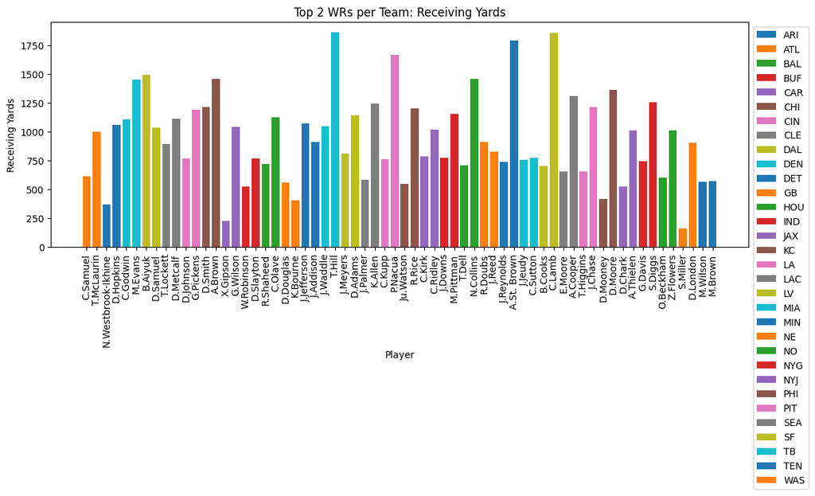

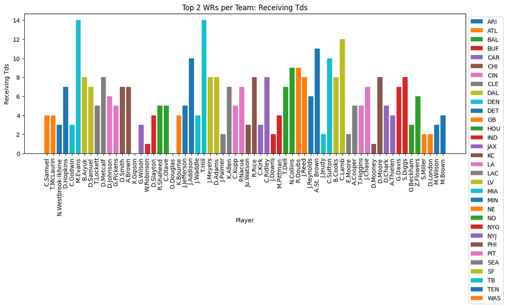

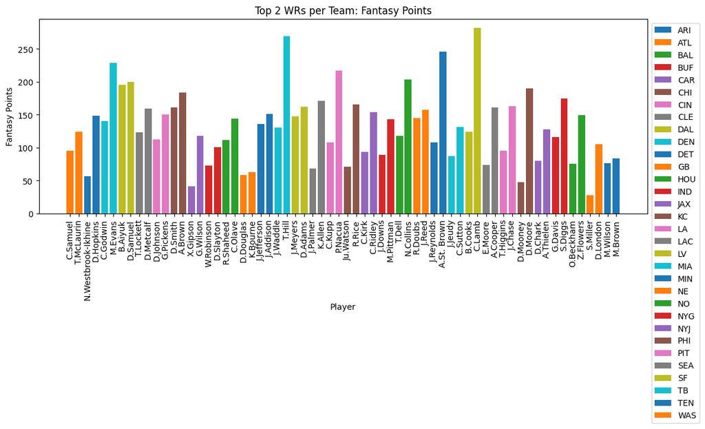

```python
# Filter data for WR position
wr_stats = player_stats[player_stats['position_group'] == 'WR']

# Check if there are wide receivers in the dataset
if wr_stats.empty:
    print("No wide receivers found in the dataset.")
else:
    # Select relevant columns for WR statistics
    relevant_stats_columns = ['player_name', 'receiving_yards', 'receiving_tds', 'fantasy_points', 'fantasy_points_ppr']

    # Group data by player name and sum up the statistics for each player
    wr_totals = wr_stats.groupby(['player_name', 'recent_team'])[relevant_stats_columns[1:]].sum().reset_index()

    # Get the best two WRs from each team
    best_wr_per_team = wr_totals.sort_values(by='fantasy_points', ascending=False).groupby('recent_team').head(2)

    # Create separate plots for receiving yards, receiving touchdowns, and fantasy points
    for stat in ['receiving_yards', 'receiving_tds', 'fantasy_points']:
        # Create a new figure
        plt.figure(figsize=(12, 6))

        # Iterate over each team and plot the data for the best two WRs
        for team, group in best_wr_per_team.groupby('recent_team'):
            plt.bar(group['player_name'], group[stat], label=team)

        # Set plot title and labels
        plt.title(f'Top 2 WRs per Team: {stat.replace("_", " ").title()}')
        plt.xlabel('Player')
        plt.ylabel(stat.replace("_", " ").title())
        plt.xticks(rotation=90, ha='center')  # Rotate x-axis labels vertically
        plt.gca().invert_xaxis()  # Invert x-axis to display player names vertically

        # Add legend outside the plot
        plt.legend(loc='upper left', bbox_to_anchor=(1, 1))

        # Show plot
        plt.tight_layout()
        plt.show()
```

```python
# Filter data for WR position
wr_stats = player_stats[player_stats['position_group'] == 'WR']

# Check if there are wide receivers in the dataset
if wr_stats.empty:
    print("No wide receivers found in the dataset.")
else:
    # Select relevant columns for WR statistics
    relevant_stats_columns = ['player_name', 'fantasy_points']

    # Group data by player name and sum up the statistics for each player
    wr_totals = wr_stats.groupby('player_name')[relevant_stats_columns[1]].sum().reset_index()

    # Sort WRs based on fantasy points and get the top 10
    top_10_wrs = wr_totals.sort_values(by='fantasy_points', ascending=False).head(10)

    # Display the top 10 WRs
    print("Top 10 WRs based on fantasy points:")
    print(tabulate(top_10_wrs, headers='keys', tablefmt='pretty', showindex=False))
```

```
Top 10 WRs based on fantasy points:
+-------------+----------------+
| player_name | fantasy_points |
+-------------+----------------+
|   C.Lamb    |     281.7      |
|   T.Hill    |     269.6      |
| A.St. Brown |     245.5      |
|   M.Evans   |     229.0      |
|   D.Moore   |     219.6      |
|   P.Nacua   |     217.4      |
|  N.Collins  |     203.2      |
|  D.Samuel   |     199.8      |
|   B.Aiyuk   |     195.1      |
|   A.Brown   |     183.6      |
+-------------+----------------+
```

## Part 2: How would their averages simulate in another season?

Step 5: Get the averages of the starting WRs and save them to a csv to run a simulation

```python
# Filter data for WR position
wr_stats = player_stats[player_stats['position_group'] == 'WR']

# Define the list of desired players
desired_players = ['C.Lamb', 'T.Hill', 'A.St. Brown', 'M.Evans', 'P.Nacua', 'N.Collins', 'D.Samuel', 'B.Aiyuk',
                   'D.Moore', 'A.Brown', 'S.Diggs', 'K.Allen', 'R.Rice', 'J.Chase', 'D.Adams', 'D.Smith',
                   'A.Cooper', 'D.Metcalf', 'J.Reed', 'C.Ridley', 'J.Addison', 'G.Pickens', 'Z.Flowers',
                   'D.Hopkins', 'J.Meyers', 'R.Doubs', 'C.Olave', 'M.Pittman', 'C.Godwin', 'J.Jefferson',
                   'C.Sutton', 'J.Waddle', 'A.Thielen', 'B.Cooks', 'T.McLaurin', 'T.Lockett', 'G.Wilson',
                   'T.Dell', 'G.Davis', 'D.Johnson', 'R.Shaheed', 'C.Kupp', 'J.Reynolds', 'D.London',
                   'D.Slayton', 'T.Higgins', 'C.Samuel', 'C.Kirk', 'J.Downs', 'J.Jeudy', 'M.Brown', 'D.Chark',
                   'M.Wilson', 'O.Beckham', 'E.Moore', 'W.Robinson', 'Ju.Watson', 'J.Palmer', 'K.Bourne',
                   'D.Douglas', 'N.Westbrook-Ikhine', 'D.Mooney', 'X.Gipson', 'S.Miller']

# Filter out players not in the desired list
wr_stats = wr_stats[wr_stats['player_name'].isin(desired_players)]

# Select relevant columns for WR statistics
relevant_stats_columns = ['player_name', 'receptions', 'receiving_yards', 'receiving_tds', 'fantasy_points']

# Group data by player name and find the best 2 WRs for each player
best_wr_per_player = wr_stats.groupby(['player_name', 'recent_team']).apply(lambda x: x.nlargest(2, 'fantasy_points')).reset_index(drop=True)

# Calculate the average statistics for each team's best 2 WRs
avg_stats_per_team = best_wr_per_player.groupby(['recent_team', 'player_name'])[relevant_stats_columns[1:]].mean()

# Save the average statistics to a CSV file
avg_stats_per_team.to_csv("average_stats_per_WR_team.csv")

print("CSV file 'average_stats_per_WR_team.csv' has been saved successfully.")
```

```
CSV file 'average_stats_per_WR_team.csv' has been saved successfully.
```

Step 6: Run a simulation.

This is a rough simulation of how the players will perform agisnst all 32 teams. Every team has a grade based on how their defense performed last year.

```python
# Load average stats for each starting WR
avg_stats_per_wr = pd.read_csv("average_stats_per_WR_team.csv")

# Create an empty list to store DataFrames of predicted stats
predicted_stats_list = []

# Define mean and standard deviation for random variations
mean_variation = 0  # Mean of the variation (no change from base prediction)
std_deviation = 5   # Standard deviation for randomness

# Iterate over each starting WR
for _, wr_row in avg_stats_per_wr.iterrows():
    player_name = wr_row["player_name"]

    # Create a list to store predicted stats for the current WR
    wr_predicted_stats = []

    # Iterate over each team
    for _, team_row in defense_grades.iterrows():
        team_name = team_row["team_name"]
        defense_grade = team_row["grade"]

        # Calculate predicted stats based on WR's average stats and defense grade
        # Introduce randomness using normal distribution
        receptions_variation = np.random.normal(mean_variation, std_deviation)
        receiving_yards_variation = np.random.normal(mean_variation, std_deviation)
        receiving_tds_variation = np.random.normal(mean_variation, std_deviation)

        predicted_receptions = wr_row["receptions"] * (32 - defense_grade) / 32 * (1 + receptions_variation/100)
        predicted_receiving_yards = wr_row["receiving_yards"] * (32 - defense_grade) / 32 * (1 + receiving_yards_variation/100)
        predicted_receiving_tds = wr_row["receiving_tds"] * (32 - defense_grade) / 32 * (1 + receiving_tds_variation/100)

        # Append the predicted stats to the list
        wr_predicted_stats.append({
            "player_name": player_name,
            "team_name": team_name,
            "predicted_receptions": predicted_receptions,
            "predicted_receiving_yards": predicted_receiving_yards,
            "predicted_receiving_tds": predicted_receiving_tds
        })

    # Convert the list of dictionaries to a DataFrame
    wr_predicted_stats_df = pd.DataFrame(wr_predicted_stats)

    # Append the DataFrame for the current WR to the list
    predicted_stats_list.append(wr_predicted_stats_df)

# Concatenate all DataFrames in the list into a single DataFrame
predicted_stats = pd.concat(predicted_stats_list)

# Save the predicted stats to a CSV file
predicted_stats.to_csv("predicted_WR_stats.csv", index=False)

print("Simulation completed. Predicted stats saved to 'predicted_WR_stats.csv'.")
```

```
Simulation completed. Predicted stats saved to 'predicted_WR_stats.csv'.
```

Step 7: Calculate the mean of every game. This value will give us a rough estimate of the mean performence.

```python
# Read the CSV file into a DataFrame
df = pd.read_csv("predicted_WR_stats.csv")

# Convert relevant columns to numeric types
numeric_cols = ['predicted_receptions', 'predicted_receiving_yards', 'predicted_receiving_tds']
df[numeric_cols] = df[numeric_cols].apply(pd.to_numeric, errors='coerce')

# Filter out rows with non-numeric values in the numeric columns
df = df.dropna(subset=numeric_cols)

# Group by player_name and calculate the mean for each player's statistics
df_mean = df.groupby('player_name')[numeric_cols].mean()

# Reset index to make player_name a column again
df_mean.reset_index(inplace=True)

# Display the resulting DataFrame
print(tabulate(df_mean, headers='keys', tablefmt='fancy_grid'))

# Save the resulting DataFrame to a CSV file
df_mean.to_csv("mean_predicted_WR_stats.csv", index=False)
```

```
╒════╤════════════════════╤════════════════════════╤═════════════════════════════╤═══════════════════════════╕
│    │ player_name        │   predicted_receptions │   predicted_receiving_yards │   predicted_receiving_tds │
╞════╪════════════════════╪════════════════════════╪═════════════════════════════╪═══════════════════════════╡
│  0 │ A.Brown            │               4.04402  │                     74.0383 │                  0.970665 │
├────┼────────────────────┼────────────────────────┼─────────────────────────────┼───────────────────────────┤
│  1 │ A.Cooper           │               3.84929  │                     98.4039 │                  0.726847 │
├────┼────────────────────┼────────────────────────┼─────────────────────────────┼───────────────────────────┤
│  2 │ A.St. Brown        │               3.66369  │                     71.7919 │                  0.477172 │
├────┼────────────────────┼────────────────────────┼─────────────────────────────┼───────────────────────────┤
│  3 │ A.Thielen          │               5.4308   │                     62.9522 │                  0.48539  │
├────┼────────────────────┼────────────────────────┼─────────────────────────────┼───────────────────────────┤
│  4 │ B.Aiyuk            │               3.17043  │                     70.4268 │                  0.717737 │
├────┼────────────────────┼────────────────────────┼─────────────────────────────┼───────────────────────────┤
│  5 │ B.Cooks            │               3.15365  │                     59.0536 │                  0.477556 │
├────┼────────────────────┼────────────────────────┼─────────────────────────────┼───────────────────────────┤
│  6 │ C.Godwin           │               3.16749  │                     58.6913 │                  0.242221 │
├────┼────────────────────┼────────────────────────┼─────────────────────────────┼───────────────────────────┤
│  7 │ C.Kirk             │               2.40225  │                     35.0487 │                  0.48335  │
├────┼────────────────────┼────────────────────────┼─────────────────────────────┼───────────────────────────┤
│  8 │ C.Kupp             │               3.61312  │                     63.5818 │                  0.486759 │
├────┼────────────────────┼────────────────────────┼─────────────────────────────┼───────────────────────────┤
│  9 │ C.Lamb             │               6.01524  │                     94.1926 │                  0.728006 │
├────┼────────────────────┼────────────────────────┼─────────────────────────────┼───────────────────────────┤
│ 10 │ C.Olave            │               3.57646  │                     53.179  │                  0.240355 │
├────┼────────────────────┼────────────────────────┼─────────────────────────────┼───────────────────────────┤
│ 11 │ C.Ridley           │               3.15668  │                     46.6475 │                  0.967099 │
├────┼────────────────────┼────────────────────────┼─────────────────────────────┼───────────────────────────┤
│ 12 │ C.Samuel           │               2.65682  │                     25.7586 │                  0.718589 │
├────┼────────────────────┼────────────────────────┼─────────────────────────────┼───────────────────────────┤
│ 13 │ C.Sutton           │               1.96259  │                     36.7637 │                  0.486189 │
├────┼────────────────────┼────────────────────────┼─────────────────────────────┼───────────────────────────┤
│ 14 │ D.Adams            │               6.31164  │                     72.1127 │                  0.973709 │
├────┼────────────────────┼────────────────────────┼─────────────────────────────┼───────────────────────────┤
│ 15 │ D.Chark            │               2.46037  │                     44.9967 │                  0.725842 │
├────┼────────────────────┼────────────────────────┼─────────────────────────────┼───────────────────────────┤
│ 16 │ D.Douglas          │               2.44757  │                     34.2147 │                  0        │
├────┼────────────────────┼────────────────────────┼─────────────────────────────┼───────────────────────────┤
│ 17 │ D.Hopkins          │               2.6346   │                     60.8348 │                  0.968375 │
├────┼────────────────────┼────────────────────────┼─────────────────────────────┼───────────────────────────┤
│ 18 │ D.Johnson          │               2.62429  │                     42.556  │                  0.483818 │
```

[output cut: 76 more lines]

```
├────┼────────────────────┼────────────────────────┼─────────────────────────────┼───────────────────────────┤
│ 57 │ T.Higgins          │               3.08725  │                     55.4412 │                  0.729695 │
├────┼────────────────────┼────────────────────────┼─────────────────────────────┼───────────────────────────┤
│ 58 │ T.Hill             │               3.8703   │                     91.4556 │                  0.978367 │
├────┼────────────────────┼────────────────────────┼─────────────────────────────┼───────────────────────────┤
│ 59 │ T.Lockett          │               3.9245   │                     36.7361 │                  0.722441 │
├────┼────────────────────┼────────────────────────┼─────────────────────────────┼───────────────────────────┤
│ 60 │ T.McLaurin         │               2.66919  │                     50.4652 │                  0.4842   │
├────┼────────────────────┼────────────────────────┼─────────────────────────────┼───────────────────────────┤
│ 61 │ W.Robinson         │               2.90169  │                     32.3885 │                  0        │
├────┼────────────────────┼────────────────────────┼─────────────────────────────┼───────────────────────────┤
│ 62 │ X.Gipson           │               1.4534   │                     19.2818 │                  0        │
├────┼────────────────────┼────────────────────────┼─────────────────────────────┼───────────────────────────┤
│ 63 │ Z.Flowers          │               1.97826  │                     32.136  │                  0.483037 │
╘════╧════════════════════╧════════════════════════╧═════════════════════════════╧═══════════════════════════╛
```

Step 8: Display the fantasy points based on the mean results from the simulation.

```python
# Read the CSV file into a DataFrame
df = pd.read_csv("mean_predicted_WR_stats.csv")

# Define the multipliers for fantasy points
receiving_yards_multiplier = 0.1
receptions_multiplier = 1
td_multiplier = 6

# Calculate fantasy points for receiving yards, receptions, and touchdowns
df['fantasy_points_receiving_yards'] = df['predicted_receiving_yards'] * receiving_yards_multiplier
df['fantasy_points_receptions'] = df['predicted_receptions'] * receptions_multiplier
df['fantasy_points_tds'] = df['predicted_receiving_tds'] * td_multiplier

# Calculate total fantasy points
df['total_fantasy_points'] = df['fantasy_points_receiving_yards'] + df['fantasy_points_receptions'] + df['fantasy_points_tds']

# Select only the specified columns
df_selected = df[['player_name', 'fantasy_points_receiving_yards', 'fantasy_points_receptions', 'fantasy_points_tds', 'total_fantasy_points']]

# Display the selected DataFrame
print(tabulate(df_selected, headers='keys', tablefmt='fancy_grid'))
```

```
╒════╤════════════════════╤══════════════════════════════════╤═════════════════════════════╤══════════════════════╤════════════════════════╕
│    │ player_name        │   fantasy_points_receiving_yards │   fantasy_points_receptions │   fantasy_points_tds │   total_fantasy_points │
╞════╪════════════════════╪══════════════════════════════════╪═════════════════════════════╪══════════════════════╪════════════════════════╡
│  0 │ A.Brown            │                          7.40383 │                    4.04402  │              5.82399 │               17.2718  │
├────┼────────────────────┼──────────────────────────────────┼─────────────────────────────┼──────────────────────┼────────────────────────┤
│  1 │ A.Cooper           │                          9.84039 │                    3.84929  │              4.36108 │               18.0508  │
├────┼────────────────────┼──────────────────────────────────┼─────────────────────────────┼──────────────────────┼────────────────────────┤
│  2 │ A.St. Brown        │                          7.17919 │                    3.66369  │              2.86303 │               13.7059  │
├────┼────────────────────┼──────────────────────────────────┼─────────────────────────────┼──────────────────────┼────────────────────────┤
│  3 │ A.Thielen          │                          6.29522 │                    5.4308   │              2.91234 │               14.6384  │
├────┼────────────────────┼──────────────────────────────────┼─────────────────────────────┼──────────────────────┼────────────────────────┤
│  4 │ B.Aiyuk            │                          7.04268 │                    3.17043  │              4.30642 │               14.5195  │
├────┼────────────────────┼──────────────────────────────────┼─────────────────────────────┼──────────────────────┼────────────────────────┤
│  5 │ B.Cooks            │                          5.90536 │                    3.15365  │              2.86533 │               11.9243  │
├────┼────────────────────┼──────────────────────────────────┼─────────────────────────────┼──────────────────────┼────────────────────────┤
│  6 │ C.Godwin           │                          5.86913 │                    3.16749  │              1.45333 │               10.49    │
├────┼────────────────────┼──────────────────────────────────┼─────────────────────────────┼──────────────────────┼────────────────────────┤
│  7 │ C.Kirk             │                          3.50487 │                    2.40225  │              2.9001  │                8.80722 │
├────┼────────────────────┼──────────────────────────────────┼─────────────────────────────┼──────────────────────┼────────────────────────┤
│  8 │ C.Kupp             │                          6.35818 │                    3.61312  │              2.92055 │               12.8918  │
├────┼────────────────────┼──────────────────────────────────┼─────────────────────────────┼──────────────────────┼────────────────────────┤
│  9 │ C.Lamb             │                          9.41926 │                    6.01524  │              4.36803 │               19.8025  │
├────┼────────────────────┼──────────────────────────────────┼─────────────────────────────┼──────────────────────┼────────────────────────┤
│ 10 │ C.Olave            │                          5.3179  │                    3.57646  │              1.44213 │               10.3365  │
├────┼────────────────────┼──────────────────────────────────┼─────────────────────────────┼──────────────────────┼────────────────────────┤
│ 11 │ C.Ridley           │                          4.66475 │                    3.15668  │              5.80259 │               13.624   │
├────┼────────────────────┼──────────────────────────────────┼─────────────────────────────┼──────────────────────┼────────────────────────┤
│ 12 │ C.Samuel           │                          2.57586 │                    2.65682  │              4.31153 │                9.54421 │
├────┼────────────────────┼──────────────────────────────────┼─────────────────────────────┼──────────────────────┼────────────────────────┤
│ 13 │ C.Sutton           │                          3.67637 │                    1.96259  │              2.91713 │                8.55609 │
├────┼────────────────────┼──────────────────────────────────┼─────────────────────────────┼──────────────────────┼────────────────────────┤
│ 14 │ D.Adams            │                          7.21127 │                    6.31164  │              5.84226 │               19.3652  │
├────┼────────────────────┼──────────────────────────────────┼─────────────────────────────┼──────────────────────┼────────────────────────┤
│ 15 │ D.Chark            │                          4.49967 │                    2.46037  │              4.35505 │               11.3151  │
├────┼────────────────────┼──────────────────────────────────┼─────────────────────────────┼──────────────────────┼────────────────────────┤
│ 16 │ D.Douglas          │                          3.42147 │                    2.44757  │              0       │                5.86904 │
├────┼────────────────────┼──────────────────────────────────┼─────────────────────────────┼──────────────────────┼────────────────────────┤
│ 17 │ D.Hopkins          │                          6.08348 │                    2.6346   │              5.81025 │               14.5283  │
├────┼────────────────────┼──────────────────────────────────┼─────────────────────────────┼──────────────────────┼────────────────────────┤
│ 18 │ D.Johnson          │                          4.2556  │                    2.62429  │              2.90291 │                9.7828  │
```

[output cut: 76 more lines]

```
├────┼────────────────────┼──────────────────────────────────┼─────────────────────────────┼──────────────────────┼────────────────────────┤
│ 57 │ T.Higgins          │                          5.54412 │                    3.08725  │              4.37817 │               13.0095  │
├────┼────────────────────┼──────────────────────────────────┼─────────────────────────────┼──────────────────────┼────────────────────────┤
│ 58 │ T.Hill             │                          9.14556 │                    3.8703   │              5.8702  │               18.8861  │
├────┼────────────────────┼──────────────────────────────────┼─────────────────────────────┼──────────────────────┼────────────────────────┤
│ 59 │ T.Lockett          │                          3.67361 │                    3.9245   │              4.33465 │               11.9328  │
├────┼────────────────────┼──────────────────────────────────┼─────────────────────────────┼──────────────────────┼────────────────────────┤
│ 60 │ T.McLaurin         │                          5.04652 │                    2.66919  │              2.9052  │               10.6209  │
├────┼────────────────────┼──────────────────────────────────┼─────────────────────────────┼──────────────────────┼────────────────────────┤
│ 61 │ W.Robinson         │                          3.23885 │                    2.90169  │              0       │                6.14054 │
├────┼────────────────────┼──────────────────────────────────┼─────────────────────────────┼──────────────────────┼────────────────────────┤
│ 62 │ X.Gipson           │                          1.92818 │                    1.4534   │              0       │                3.38158 │
├────┼────────────────────┼──────────────────────────────────┼─────────────────────────────┼──────────────────────┼────────────────────────┤
│ 63 │ Z.Flowers          │                          3.2136  │                    1.97826  │              2.89822 │                8.09008 │
╘════╧════════════════════╧══════════════════════════════════╧═════════════════════════════╧══════════════════════╧════════════════════════╛
```

```python
# Read the CSV file into a DataFrame
df = pd.read_csv("mean_predicted_WR_stats.csv")

# Define the multipliers for fantasy points
receiving_yards_multiplier = 0.1
receptions_multiplier = 1
td_multiplier = 6

# Calculate fantasy points for receiving yards, receptions, and touchdowns
df['fantasy_points_receiving_yards'] = df['predicted_receiving_yards'] * receiving_yards_multiplier
df['fantasy_points_receptions'] = df['predicted_receptions'] * receptions_multiplier
df['fantasy_points_tds'] = df['predicted_receiving_tds'] * td_multiplier

# Calculate total fantasy points
df['total_fantasy_points'] = df['fantasy_points_receiving_yards'] + df['fantasy_points_receptions'] + df['fantasy_points_tds']

# Select only the specified columns
df_selected = df[['player_name', 'total_fantasy_points']]

# Sort the DataFrame by total fantasy points in descending order
df_selected_sorted = df_selected.sort_values(by='total_fantasy_points', ascending=False)

# Display the top 10 WRs based on total fantasy points
top_10_wr = df_selected_sorted.head(10)
print(tabulate(top_10_wr, headers='keys', tablefmt='fancy_grid'))
```

```
╒════╤═══════════════╤════════════════════════╕
│    │ player_name   │   total_fantasy_points │
╞════╪═══════════════╪════════════════════════╡
│ 31 │ J.Chase       │                20.4925 │
├────┼───────────────┼────────────────────────┤
│  9 │ C.Lamb        │                19.8025 │
├────┼───────────────┼────────────────────────┤
│ 14 │ D.Adams       │                19.3652 │
├────┼───────────────┼────────────────────────┤
│ 41 │ K.Allen       │                19.3458 │
├────┼───────────────┼────────────────────────┤
│ 58 │ T.Hill        │                18.8861 │
├────┼───────────────┼────────────────────────┤
│  1 │ A.Cooper      │                18.0508 │
├────┼───────────────┼────────────────────────┤
│  0 │ A.Brown       │                17.2718 │
├────┼───────────────┼────────────────────────┤
│ 47 │ N.Collins     │                17.0345 │
├────┼───────────────┼────────────────────────┤
│ 33 │ J.Jefferson   │                15.8814 │
├────┼───────────────┼────────────────────────┤
│ 50 │ P.Nacua       │                15.6542 │
╘════╧═══════════════╧════════════════════════╛
```

### Question 2 Conclusion:

The results of this simulation are more realistic than the QB's. Still a lot of variation to what could actually happen due to the unrealistic expectation that the WR will always play their average from last year and the stat differential between the highest-scored defenses and lowest-scored defenses. Another discrepancy in this data is it does not account for injured players last year. Someone like Justin Jefferson did surprise me by breaking the top 10 while spending most of the season injured.

# Question 3:

## Part 1: What RBs had the best performances in 2023?

Step 1: Get the totals for every RB in the dataset.

```python
# Filter data for RB position
rb_stats = player_stats[player_stats['position_group'] == 'RB']

# Check if there are running backs in the dataset
if rb_stats.empty:
    print("No running backs found in the dataset.")
else:
    # Select relevant columns for RB statistics
    relevant_stats_columns = ['player_name', 'rushing_yards', 'rushing_tds', 'receptions', 'receiving_yards', 'receiving_tds', 'fantasy_points', 'fantasy_points_ppr']

    # Group data by player name and sum up the statistics for each player
    rb_totals = rb_stats.groupby('player_name')[relevant_stats_columns[1:]].sum().reset_index()

    # Display the total statistics for each RB
    print("Total statistics for RB position by player for the 2023 season:")
    print(tabulate(rb_totals, headers='keys', tablefmt='pretty'))
```

```
Total statistics for RB position by player for the 2023 season:
+-----+-------------------+---------------+-------------+------------+-----------------+---------------+--------------------+--------------------+
|     |    player_name    | rushing_yards | rushing_tds | receptions | receiving_yards | receiving_tds |   fantasy_points   | fantasy_points_ppr |
+-----+-------------------+---------------+-------------+------------+-----------------+---------------+--------------------+--------------------+
|  0  |    A.Abdullah     |      89       |      0      |     19     |       131       |       0       |        22.0        |        41.0        |
|  1  |      A.Armah      |       0       |      0      |     3      |       13        |       0       |        1.3         |        4.3         |
|  2  |      A.Beck       |       3       |      1      |     11     |       55        |       2       |        27.8        |        38.8        |
|  3  |     A.Dillon      |      613      |      2      |     22     |       223       |       0       |        95.6        |       117.6        |
|  4  |     A.Ekeler      |      628      |      5      |     51     |       436       |       1       |       134.4        |       185.4        |
|  5  |     A.Gibson      |      265      |      1      |     48     |       389       |       2       |        79.4        |       127.4        |
|  6  |     A.Ingold      |       0       |      0      |     13     |       119       |       0       |        11.9        |        24.9        |
|  7  |      A.Jones      |      882      |      5      |     34     |       254       |       1       |       149.6        |       183.6        |
|  8  |     A.Kamara      |      694      |      5      |     75     |       466       |       1       |       158.0        |       233.0        |
|  9  |    A.Mattison     |      700      |      0      |     30     |       192       |       3       |       103.2        | 133.20000000000002 |
| 10  |    A.McFarland    |       0       |      0      |     2      |       11        |       0       |        1.1         |        3.1         |
| 11  |    A.Prentice     |      12       |      0      |     2      |       12        |       0       | 0.3999999999999999 |        2.4         |
| 12  |     B.Bolden      |      31       |      1      |     0      |        0        |       0       |        11.1        |        11.1        |
| 13  |      B.Hall       |      994      |      5      |     76     |       591       |       4       |       214.5        |       290.5        |
| 14  |    B.Robinson     |     1709      |      9      |     94     |       855       |       8       |       350.4        |       444.4        |
| 15  |      B.Scott      |      86       |      0      |     4      |       52        |       0       |        13.8        |        17.8        |
| 16  |      C.Akers      |      167      |      2      |     11     |       70        |       0       | 35.699999999999996 | 46.699999999999996 |
| 17  |     C.Brooks      |      106      |      0      |     0      |        0        |       0       |        10.6        |        10.6        |
| 18  |      C.Brown      |      179      |      0      |     14     |       156       |       1       |        39.5        |        53.5        |
| 19  |     C.Edmonds     |      207      |      0      |     17     |       107       |       0       |        31.4        |        48.4        |
| 20  | C.Edwards-Helaire |      276      |      1      |     21     |       195       |       1       |        57.1        |        78.1        |
| 21  |      C.Evans      |      12       |      0      |     1      |       -1        |       0       |        1.1         |        2.1         |
| 22  |       C.Ham       |       7       |      0      |     7      |       25        |       0       | 3.1999999999999997 |        10.2        |
| 23  |     C.Hubbard     |      902      |      5      |     39     |       233       |       0       |       143.5        |       182.5        |
| 24  |    C.McCaffrey    |     1727      |     18      |     86     |       716       |       8       |       394.3        |       480.3        |
| 25  |    C.Patterson    |      181      |      0      |     9      |       38        |       1       |        27.9        |        36.9        |
| 26  |    C.Reynolds     |      180      |      2      |     5      |       47        |       0       | 32.699999999999996 | 37.699999999999996 |
| 27  |    C.Rodriguez    |      247      |      2      |     2      |       12        |       0       |        35.9        |        37.9        |
| 28  |     D.Achane      |      809      |      8      |     30     |       218       |       3       |       166.7        |       196.7        |
| 29  |      D.Cook       |      237      |      0      |     15     |       78        |       0       |        27.5        |        42.5        |
| 30  |     D.Dallas      |      36       |      0      |     6      |       26        |       0       |        6.2         |        12.2        |
| 31  |      D.Evans      |      121      |      1      |     7      |       49        |       0       |        23.0        |        30.0        |
| 32  |     D.Foreman     |      425      |      4      |     11     |       77        |       1       |        80.2        |        91.2        |
| 33  |      D.Gore       |      26       |      0      |     0      |        0        |       0       | 2.5999999999999996 | 2.5999999999999996 |
| 34  |     D.Harris      |      94       |      1      |     2      |       16        |       0       |        17.0        |        19.0        |
| 35  |    D.Henderson    |      112      |      2      |     10     |       103       |       0       |        33.5        |        43.5        |
```

[output cut: 96 more lines]

```
| 132 |     T.Etienne     |     1008      |     11      |     58     |       476       |       1       |       224.4        |       282.4        |
| 133 |     T.Goodson     |      87       |      0      |     6      |       34        |       0       | 12.100000000000001 |        18.1        |
| 134 |      T.Homer      |       0       |      0      |     0      |        0        |       0       |        0.0         |        0.0         |
| 135 |     T.Johnson     |      198      |      0      |     8      |       76        |       1       |        33.4        |        41.4        |
| 136 |      T.Jones      |      95       |      2      |     7      |       37        |       0       |        25.2        |        32.2        |
| 137 |     T.Pollard     |     1061      |      7      |     62     |       340       |       0       |       182.1        |       244.1        |
| 138 |     T.Sermon      |      160      |      0      |     3      |       13        |       0       |        17.3        |        20.3        |
| 139 |     T.Spears      |      453      |      2      |     52     |       385       |       1       | 101.80000000000001 |       153.8        |
| 140 |    T.Williams     |      69       |      0      |     7      |       10        |       0       |        7.9         |        14.9        |
| 141 |   Z.Charbonnet    |      462      |      1      |     33     |       209       |       0       |        73.1        |       106.1        |
| 142 |      Z.Evans      |      19       |      0      |     0      |        0        |       0       |        1.9         |        1.9         |
| 143 |     Z.Knight      |      13       |      0      |     1      |        8        |       0       |        2.1         |        3.1         |
| 144 |      Z.Moss       |      794      |      5      |     27     |       192       |       2       |       142.6        |       169.6        |
| 145 |      Z.White      |      451      |      1      |     15     |       98        |       0       |        58.9        |        73.9        |
+-----+-------------------+---------------+-------------+------------+-----------------+---------------+--------------------+--------------------+
```

Step 2: Refine this list to only take the best RB from each of the 32 teams.

```python
# Filter data for RB position
rb_stats = player_stats[player_stats['position_group'] == 'RB']

# Check if there are running backs in the dataset
if rb_stats.empty:
    print("No running backs found in the dataset.")
else:
    # Select relevant columns for RB statistics
    relevant_stats_columns = ['player_name', 'recent_team', 'rushing_yards', 'rushing_tds','receptions', 'receiving_yards', 'receiving_tds', 'fantasy_points', 'fantasy_points_ppr']

    # Group data by player name and sum up the statistics for each player
    rb_totals = rb_stats.groupby(['player_name', 'recent_team'])[relevant_stats_columns[2:]].sum().reset_index()

    # Get the best RB from each team
    best_rb_per_team = rb_totals.sort_values(by='fantasy_points', ascending=False).groupby('recent_team').head(1)

    # Display the best RB from each team
    print("Best running back from each team:")
    print(tabulate(best_rb_per_team, headers='keys', tablefmt='pretty'))
```

```
Best running back from each team:
+-----+--------------+-------------+---------------+-------------+------------+-----------------+---------------+--------------------+--------------------+
|     | player_name  | recent_team | rushing_yards | rushing_tds | receptions | receiving_yards | receiving_tds |   fantasy_points   | fantasy_points_ppr |
+-----+--------------+-------------+---------------+-------------+------------+-----------------+---------------+--------------------+--------------------+
| 26  | C.McCaffrey  |     SF      |     1727      |     18      |     86     |       716       |       8       |       394.3        |       480.3        |
| 128 |  R.Mostert   |     MIA     |     1045      |     18      |     26     |       172       |       3       | 245.70000000000002 |       271.7        |
| 106 |  K.Williams  |     LA      |     1205      |     12      |     33     |       215       |       3       |       230.0        |       263.0        |
| 72  |   J.Gibbs    |     DET     |     1089      |     13      |     63     |       410       |       1       |       229.9        |       292.9        |
| 132 |   R.White    |     TB      |     1117      |      6      |     69     |       588       |       4       |       226.5        |       295.5        |
| 141 |  T.Etienne   |     JAX     |     1008      |     11      |     58     |       476       |       1       |       224.4        |       282.4        |
| 63  |  I.Pacheco   |     KC      |     1248      |     10      |     56     |       304       |       2       |       223.2        |       279.2        |
| 40  |   D.Henry    |     TEN     |     1167      |     12      |     28     |       214       |       0       |       218.66       |       246.66       |
| 82  |   J.Mixon    |     CIN     |     1034      |      9      |     52     |       376       |       3       |       215.0        |       267.0        |
| 13  |    B.Hall    |     NYJ     |      994      |      5      |     76     |       591       |       4       |       214.5        |       290.5        |
| 67  |    J.Cook    |     BUF     |     1262      |      2      |     52     |       471       |       4       |       205.3        |       257.3        |
| 14  |  B.Robinson  |     ATL     |      976      |      4      |     58     |       487       |       4       |       188.3        |       246.3        |
| 60  |  G.Edwards   |     BAL     |      870      |     13      |     14     |       195       |       0       |       182.5        |       196.5        |
| 134 |  S.Barkley   |     NYG     |      962      |      6      |     41     |       280       |       4       |       182.2        |       223.2        |
| 147 |  T.Pollard   |     DAL     |     1061      |      7      |     62     |       340       |       0       |       182.1        |       244.1        |
| 66  |   J.Conner   |     ARI     |     1040      |      7      |     27     |       165       |       2       |       174.5        |       201.5        |
| 70  |    J.Ford    |     CLE     |      830      |      4      |     48     |       334       |       5       |       172.4        |       220.4        |
| 119 |   N.Harris   |     PIT     |     1072      |      8      |     31     |       185       |       0       | 171.70000000000002 | 202.70000000000002 |
| 105 |   K.Walker   |     SEA     |      905      |      8      |     29     |       259       |       1       |       170.4        |       199.4        |
| 49  |   D.Swift    |     PHI     |     1083      |      5      |     43     |       246       |       1       |       166.9        |       209.9        |
| 15  |  B.Robinson  |     WAS     |      733      |      5      |     36     |       368       |       4       |       162.1        |       198.1        |
|  8  |   A.Kamara   |     NO      |      694      |      5      |     75     |       466       |       1       |       158.0        |       233.0        |
| 48  | D.Singletary |     HOU     |      986      |      5      |     38     |       245       |       0       |       157.34       |       195.34       |
|  7  |   A.Jones    |     GB      |      882      |      5      |     34     |       254       |       1       |       149.6        |       183.6        |
| 75  |   J.Jacobs   |     LV      |      805      |      6      |     37     |       296       |       0       |       144.1        |       181.1        |
| 25  |  C.Hubbard   |     CAR     |      902      |      5      |     39     |       233       |       0       |       143.5        |       182.5        |
| 154 |    Z.Moss    |     IND     |      794      |      5      |     27     |       192       |       2       |       142.6        |       169.6        |
|  4  |   A.Ekeler   |     LAC     |      628      |      5      |     51     |       436       |       1       |       134.4        |       185.4        |
| 87  |  J.Williams  |     DEN     |      774      |      3      |     47     |       228       |       2       |       132.2        |       179.2        |
| 54  |  E.Elliott   |     NE      |      642      |      3      |     51     |       313       |       2       |       123.5        |       174.5        |
|  9  |  A.Mattison  |     MIN     |      700      |      0      |     30     |       192       |       3       |       103.2        | 133.20000000000002 |
| 96  |  K.Herbert   |     CHI     |      611      |      2      |     20     |       134       |       1       |        92.5        |       112.5        |
+-----+--------------+-------------+---------------+-------------+------------+-----------------+---------------+--------------------+--------------------+
```

Step 3: Graph the stats to visualize the best performers

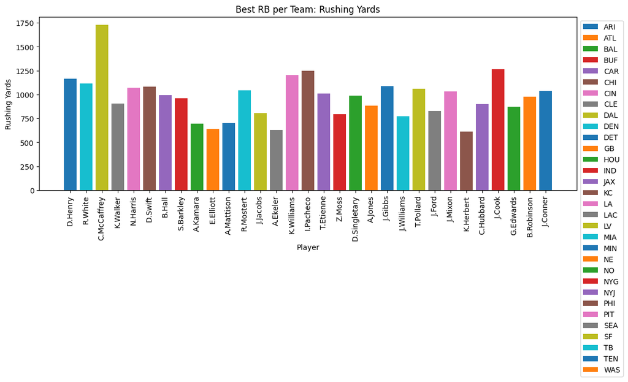

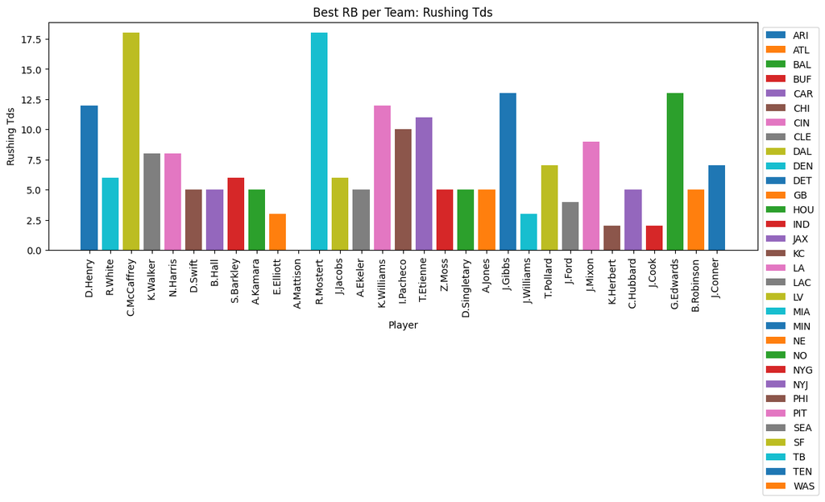

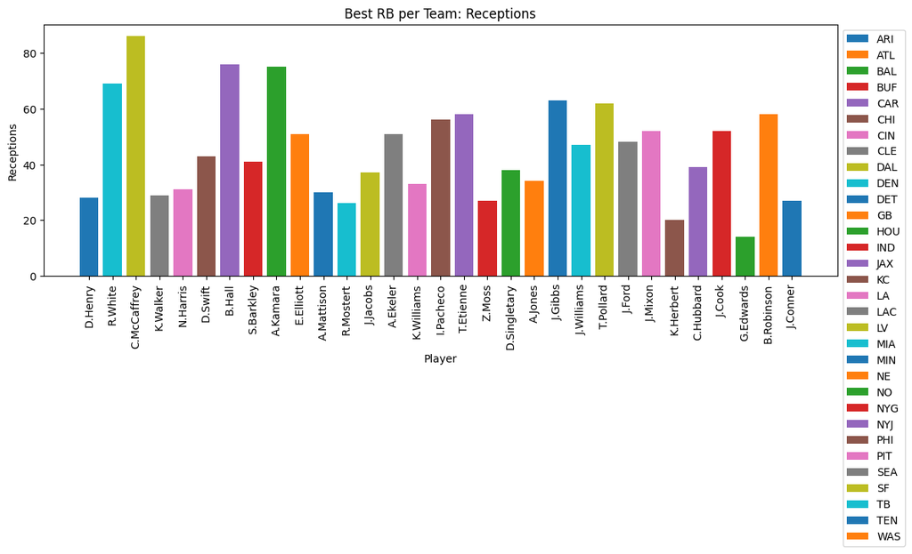

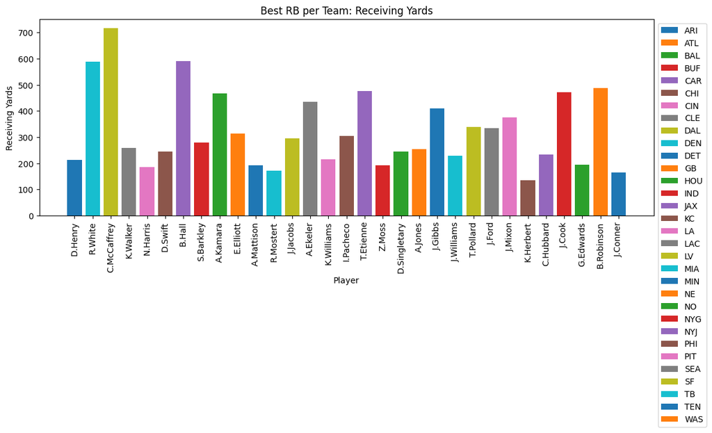

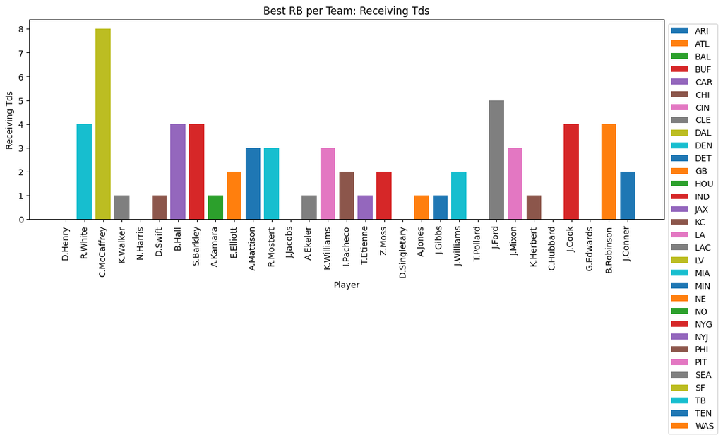

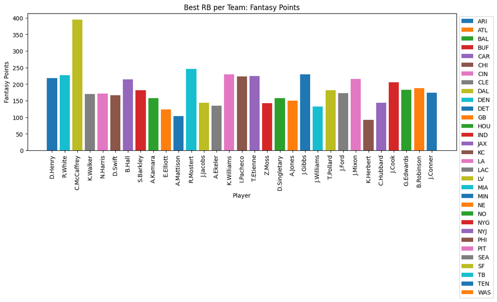

```python
# Filter data for RB position
rb_stats = player_stats[player_stats['position_group'] == 'RB']

# Check if there are running backs in the dataset
if rb_stats.empty:
    print("No running backs found in the dataset.")
else:
    # Select relevant columns for RB statistics
    relevant_stats_columns = ['player_name', 'recent_team', 'rushing_yards', 'rushing_tds','receptions', 'receiving_yards', 'receiving_tds', 'fantasy_points', 'fantasy_points_ppr']

    # Group data by player name and sum up the statistics for each player
    rb_totals = rb_stats.groupby(['player_name', 'recent_team'])[relevant_stats_columns[2:]].sum().reset_index()

    # Get the best RB from each team
    best_rb_per_team = rb_totals.sort_values(by='fantasy_points', ascending=False).groupby('recent_team').head(1)

  # Create separate plots for rushing yards, rushing touchdowns, receiving yards, receiving touchdowns, and fantasy points
for stat in ['rushing_yards', 'rushing_tds','receptions', 'receiving_yards', 'receiving_tds', 'fantasy_points']:
    # Create a new figure
    plt.figure(figsize=(12, 6))

    # Iterate over each team and plot the data for the best RB
    for team, group in best_rb_per_team.groupby('recent_team'):
        plt.bar(group['player_name'], group[stat], label=team)

    # Set plot title and labels
    plt.title(f'Best RB per Team: {stat.replace("_", " ").title()}')
    plt.xlabel('Player')
    plt.ylabel(stat.replace("_", " ").title())
    plt.xticks(rotation=90, ha='center')  # Rotate x-axis labels vertically
    plt.gca().invert_xaxis()  # Invert x-axis to display player names vertically

    # Add legend outside the plot
    plt.legend(loc='upper left', bbox_to_anchor=(1, 1))

    # Show plot
    plt.tight_layout()
    plt.show()
```

Step 4: Display a list of the 5 best fantasy performing RBs

```python
# Filter data for RB position
rb_stats = player_stats[player_stats['position_group'] == 'RB']

# Check if there are running backs in the dataset
if rb_stats.empty:
    print("No running backs found in the dataset.")
else:
    # Select relevant columns for RB statistics
    relevant_stats_columns = ['player_name', 'recent_team', 'rushing_yards', 'rushing_tds','receptions', 'receiving_yards', 'receiving_tds', 'fantasy_points', 'fantasy_points_ppr']

    # Group data by player name and sum up the statistics for each player
    rb_totals = rb_stats.groupby('player_name')[relevant_stats_columns[2:]].sum().reset_index()

    # Sort RB totals by fantasy points in descending order
    rb_totals_sorted = rb_totals.sort_values(by='fantasy_points', ascending=False)

    # Select the top 5 RBs by fantasy points
    top_5_rbs = rb_totals_sorted.head(5)

    # Display the top 5 RBs
    print("Top 5 RBs by Fantasy Points:")
    print(tabulate(top_5_rbs, headers='keys', tablefmt='fancy_grid'))
```

```
Top 5 RBs by Fantasy Points:
╒═════╤═══════════════╤═════════════════╤═══════════════╤══════════════╤═══════════════════╤═════════════════╤══════════════════╤══════════════════════╕
│     │ player_name   │   rushing_yards │   rushing_tds │   receptions │   receiving_yards │   receiving_tds │   fantasy_points │   fantasy_points_ppr │
╞═════╪═══════════════╪═════════════════╪═══════════════╪══════════════╪═══════════════════╪═════════════════╪══════════════════╪══════════════════════╡
│  24 │ C.McCaffrey   │            1727 │            18 │           86 │               716 │               8 │            394.3 │                480.3 │
├─────┼───────────────┼─────────────────┼───────────────┼──────────────┼───────────────────┼─────────────────┼──────────────────┼──────────────────────┤
│  14 │ B.Robinson    │            1709 │             9 │           94 │               855 │               8 │            350.4 │                444.4 │
├─────┼───────────────┼─────────────────┼───────────────┼──────────────┼───────────────────┼─────────────────┼──────────────────┼──────────────────────┤
│ 119 │ R.Mostert     │            1045 │            18 │           26 │               172 │               3 │            245.7 │                271.7 │
├─────┼───────────────┼─────────────────┼───────────────┼──────────────┼───────────────────┼─────────────────┼──────────────────┼──────────────────────┤
│  98 │ K.Williams    │            1205 │            12 │           33 │               215 │               3 │            230   │                263   │
├─────┼───────────────┼─────────────────┼───────────────┼──────────────┼───────────────────┼─────────────────┼──────────────────┼──────────────────────┤
│  67 │ J.Gibbs       │            1089 │            13 │           63 │               410 │               1 │            229.9 │                292.9 │
╘═════╧═══════════════╧═════════════════╧═══════════════╧══════════════╧═══════════════════╧═════════════════╧══════════════════╧══════════════════════╛
```

## Part 2: How would their averages simulate in another season?

Step 5: Get the averages of the starting RBs and save them to a csv to run a simulation

```python
# Filter data for RB position
rb_stats = player_stats[player_stats['position_group'] == 'RB']

# Define the list of desired players
desired_players = [
    'C.McCaffrey', 'R.Mostert', 'K.Williams', 'J.Gibbs', 'R.White', 'T.Etienne', 'I.Pacheco', 'D.Henry',
    'J.Mixon', 'B.Hall', 'J.Cook', 'B.Robinson', 'G.Edwards', 'S.Barkley', 'T.Pollard', 'J.Conner',
    'J.Ford', 'N.Harris', 'K.Walker', 'D.Swift', 'B.Robinson', 'A.Kamara', 'D.Singletary', 'A.Jones',
    'J.Jacobs', 'C.Hubbard', 'Z.Moss', 'A.Ekeler', 'J.Williams', 'E.Elliott', 'A.Mattison', 'K.Herbert'
]

# Filter out players not in the desired list
rb_stats = rb_stats[rb_stats['player_name'].isin(desired_players)]

# Select relevant columns for RB statistics
relevant_stats_columns = ['player_name', 'rushing_yards', 'rushing_tds','receptions', 'receiving_yards', 'receiving_tds', 'fantasy_points']

# Group data by player name and find the best RB for each player
best_rb_per_player = rb_stats.groupby(['player_name', 'recent_team']).apply(lambda x: x.nlargest(1, 'fantasy_points')).reset_index(drop=True)

# Calculate the average statistics for each team's best RB
avg_stats_per_team = best_rb_per_player.groupby(['recent_team', 'player_name'])[relevant_stats_columns[1:]].mean()

# Save the average statistics to a CSV file
avg_stats_per_team.to_csv("average_stats_per_RB_team.csv")

print("CSV file 'average_stats_per_RB_team.csv' has been saved successfully.")
```

```
CSV file 'average_stats_per_RB_team.csv' has been saved successfully.
```

Step 6: Run a simulation.

This is a rough simulation of how the players will perform agisnst all 32 teams. Every team has a grade based on how their defense performed last year.

```python
# Load average stats for each starting RB
avg_stats_per_rb = pd.read_csv("average_stats_per_RB_team.csv")

# Create an empty list to store DataFrames of predicted stats
predicted_stats_list = []

# Define mean and standard deviation for random variations
mean_variation = 0  # Mean of the variation (no change from base prediction)
std_deviation = 5   # Standard deviation for randomness

# Iterate over each starting RB
for _, rb_row in avg_stats_per_rb.iterrows():
    player_name = rb_row["player_name"]

    # Create a list to store predicted stats for the current RB
    rb_predicted_stats = []

    # Iterate over each team
    for _, team_row in defense_grades.iterrows():
        team_name = team_row["team_name"]
        defense_grade = team_row["grade"]

        # Calculate predicted stats based on RB's average stats and defense grade
        # Introduce randomness using normal distribution
        yardage_variation = np.random.normal(mean_variation, std_deviation)
        td_variation = np.random.normal(mean_variation, std_deviation)

        predicted_rushing_yards = rb_row["rushing_yards"] * (32 - defense_grade) / 32 * (1 + yardage_variation/100)
        predicted_rushing_tds = rb_row["rushing_tds"] * (32 - defense_grade) / 32 * (1 + td_variation/100)
        predicted_receptions = rb_row["receptions"] * (32 - defense_grade) / 32
        predicted_receiving_yards = rb_row["receiving_yards"] * (32 - defense_grade) / 32
        predicted_receiving_tds = rb_row["receiving_tds"] * (32 - defense_grade) / 32

        # Append the predicted stats to the list
        rb_predicted_stats.append({
            "player_name": player_name,
            "team_name": team_name,
            "predicted_rushing_yards": predicted_rushing_yards,
            "predicted_rushing_tds": predicted_rushing_tds,
            "predicted_receptions": predicted_receptions,
            "predicted_receiving_yards": predicted_receiving_yards,
            "predicted_receiving_tds": predicted_receiving_tds
        })

    # Convert the list of dictionaries to a DataFrame
    rb_predicted_stats_df = pd.DataFrame(rb_predicted_stats)

    # Append the DataFrame for the current RB to the list
    predicted_stats_list.append(rb_predicted_stats_df)

# Concatenate all DataFrames in the list into a single DataFrame
predicted_stats = pd.concat(predicted_stats_list)

# Save the predicted stats to a CSV file
predicted_stats.to_csv("predicted_RB_stats.csv", index=False)

print("Simulation completed. Predicted stats saved to 'predicted_RB_stats.csv'.")
```

```
Simulation completed. Predicted stats saved to 'predicted_RB_stats.csv'.
```

Step 7: Calculate the mean of every game. This value will give us a rough estimate of the mean performence.

```python
# Read the CSV file into a DataFrame
df = pd.read_csv("predicted_RB_stats.csv")

# Convert relevant columns to numeric types
numeric_cols = ['predicted_rushing_yards', 'predicted_rushing_tds','predicted_receptions', 'predicted_receiving_yards', 'predicted_receiving_tds']
df[numeric_cols] = df[numeric_cols].apply(pd.to_numeric, errors='coerce')

# Filter out rows with non-numeric values in the numeric columns
df = df.dropna(subset=numeric_cols)

# Group by player_name and calculate the mean for each player's statistics
df_mean = df.groupby('player_name')[numeric_cols].mean()

# Reset index to make player_name a column again
df_mean.reset_index(inplace=True)

# Display the resulting DataFrame
print(tabulate(df_mean, headers='keys', tablefmt='fancy_grid'))

# Save the resulting DataFrame to a CSV file
df_mean.to_csv("mean_predicted_RB_stats.csv", index=False)
```

```
╒════╤═══════════════╤═══════════════════════════╤═════════════════════════╤════════════════════════╤═════════════════════════════╤═══════════════════════════╕
│    │ player_name   │   predicted_rushing_yards │   predicted_rushing_tds │   predicted_receptions │   predicted_receiving_yards │   predicted_receiving_tds │
╞════╪═══════════════╪═══════════════════════════╪═════════════════════════╪════════════════════════╪═════════════════════════════╪═══════════════════════════╡
│  0 │ A.Ekeler      │                   57.0679 │                0.496337 │               1.9375   │                    22.7656  │                  0        │
├────┼───────────────┼───────────────────────────┼─────────────────────────┼────────────────────────┼─────────────────────────────┼───────────────────────────┤
│  1 │ A.Jones       │                   57.0911 │                1.4649   │               0.484375 │                     6.29688 │                  0        │
├────┼───────────────┼───────────────────────────┼─────────────────────────┼────────────────────────┼─────────────────────────────┼───────────────────────────┤
│  2 │ A.Kamara      │                   28.4071 │                0.481772 │               1.9375   │                    24.7031  │                  0.484375 │
├────┼───────────────┼───────────────────────────┼─────────────────────────┼────────────────────────┼─────────────────────────────┼───────────────────────────┤
│  3 │ A.Mattison    │                   20.986  │                0        │               0.96875  │                    23.7344  │                  0.484375 │
├────┼───────────────┼───────────────────────────┼─────────────────────────┼────────────────────────┼─────────────────────────────┼───────────────────────────┤
│  4 │ B.Hall        │                   46.0941 │                0.960988 │               5.8125   │                    46.5     │                  0        │
├────┼───────────────┼───────────────────────────┼─────────────────────────┼────────────────────────┼─────────────────────────────┼───────────────────────────┤
│  5 │ B.Robinson    │                   43.2925 │                0.726049 │               1.21094  │                    17.9219  │                  0.242188 │
├────┼───────────────┼───────────────────────────┼─────────────────────────┼────────────────────────┼─────────────────────────────┼───────────────────────────┤
│  6 │ C.Hubbard     │                   51.4921 │                0.975468 │               0        │                     0       │                  0        │
├────┼───────────────┼───────────────────────────┼─────────────────────────┼────────────────────────┼─────────────────────────────┼───────────────────────────┤
│  7 │ C.McCaffrey   │                   50.4567 │                1.4501   │               3.39062  │                    34.3906  │                  0.484375 │
├────┼───────────────┼───────────────────────────┼─────────────────────────┼────────────────────────┼─────────────────────────────┼───────────────────────────┤
│  8 │ D.Henry       │                   49.4968 │                0.966025 │               0.484375 │                     8.71875 │                  0        │
├────┼───────────────┼───────────────────────────┼─────────────────────────┼────────────────────────┼─────────────────────────────┼───────────────────────────┤
│  9 │ D.Singletary  │                   73.7044 │                0.486624 │               0.484375 │                     5.32812 │                  0        │
├────┼───────────────┼───────────────────────────┼─────────────────────────┼────────────────────────┼─────────────────────────────┼───────────────────────────┤
│ 10 │ D.Swift       │                   84.1255 │                0.487374 │               1.45312  │                     2.90625 │                  0        │
├────┼───────────────┼───────────────────────────┼─────────────────────────┼────────────────────────┼─────────────────────────────┼───────────────────────────┤
│ 11 │ E.Elliott     │                   32.6782 │                0        │               3.39062  │                    34.875   │                  0.484375 │
```

[output cut: 39 more lines]

Step 8: Display the fantasy points based on the mean results from the simulation.

```python
# Read the CSV file into a DataFrame
df = pd.read_csv("mean_predicted_RB_stats.csv")

# Define the multipliers for fantasy points
rushing_yards_multiplier = 0.1
rushing_tds_multiplier = 6
receptions_multiplier = 1
receiving_yards_multiplier = 0.1
receiving_tds_multiplier = 6

# Calculate fantasy points for rushing yards, rushing touchdowns, receiving yards, and receiving touchdowns
df['fantasy_points_rushing_yards'] = df['predicted_rushing_yards'] * rushing_yards_multiplier
df['fantasy_points_rushing_tds'] = df['predicted_rushing_tds'] * rushing_tds_multiplier
df['fantasy_points_receptions'] = df['predicted_receptions'] * receptions_multiplier  # Fixed typo here
df['fantasy_points_receiving_yards'] = df['predicted_receiving_yards'] * receiving_yards_multiplier
df['fantasy_points_receiving_tds'] = df['predicted_receiving_tds'] * receiving_tds_multiplier

# Calculate total fantasy points
df['total_fantasy_points'] = (df['fantasy_points_rushing_yards'] + df['fantasy_points_rushing_tds'] +
                              df['fantasy_points_receptions'] + df['fantasy_points_receiving_yards'] +
                              df['fantasy_points_receiving_tds'])

# Select only the specified columns
df_selected = df[['player_name', 'fantasy_points_rushing_yards', 'fantasy_points_rushing_tds',
                  'fantasy_points_receptions', 'fantasy_points_receiving_yards', 'fantasy_points_receiving_tds',
                  'total_fantasy_points']]

# Display the selected DataFrame
print(tabulate(df_selected, headers='keys', tablefmt='fancy_grid'))
```

```
╒════╤═══════════════╤════════════════════════════════╤══════════════════════════════╤═════════════════════════════╤══════════════════════════════════╤════════════════════════════════╤════════════════════════╕
│    │ player_name   │   fantasy_points_rushing_yards │   fantasy_points_rushing_tds │   fantasy_points_receptions │   fantasy_points_receiving_yards │   fantasy_points_receiving_tds │   total_fantasy_points │
╞════╪═══════════════╪════════════════════════════════╪══════════════════════════════╪═════════════════════════════╪══════════════════════════════════╪════════════════════════════════╪════════════════════════╡
│  0 │ A.Ekeler      │                        5.70679 │                     2.97802  │                    1.9375   │                         2.27656  │                        0       │               12.8989  │
├────┼───────────────┼────────────────────────────────┼──────────────────────────────┼─────────────────────────────┼──────────────────────────────────┼────────────────────────────────┼────────────────────────┤
│  1 │ A.Jones       │                        5.70911 │                     8.78938  │                    0.484375 │                         0.629688 │                        0       │               15.6125  │
├────┼───────────────┼────────────────────────────────┼──────────────────────────────┼─────────────────────────────┼──────────────────────────────────┼────────────────────────────────┼────────────────────────┤
│  2 │ A.Kamara      │                        2.84071 │                     2.89063  │                    1.9375   │                         2.47031  │                        2.90625 │               13.0454  │
├────┼───────────────┼────────────────────────────────┼──────────────────────────────┼─────────────────────────────┼──────────────────────────────────┼────────────────────────────────┼────────────────────────┤
│  3 │ A.Mattison    │                        2.0986  │                     0        │                    0.96875  │                         2.37344  │                        2.90625 │                8.34703 │
├────┼───────────────┼────────────────────────────────┼──────────────────────────────┼─────────────────────────────┼──────────────────────────────────┼────────────────────────────────┼────────────────────────┤
│  4 │ B.Hall        │                        4.60941 │                     5.76593  │                    5.8125   │                         4.65     │                        0       │               20.8378  │
├────┼───────────────┼────────────────────────────────┼──────────────────────────────┼─────────────────────────────┼──────────────────────────────────┼────────────────────────────────┼────────────────────────┤
│  5 │ B.Robinson    │                        4.32925 │                     4.3563   │                    1.21094  │                         1.79219  │                        1.45312 │               13.1418  │
├────┼───────────────┼────────────────────────────────┼──────────────────────────────┼─────────────────────────────┼──────────────────────────────────┼────────────────────────────────┼────────────────────────┤
│  6 │ C.Hubbard     │                        5.14921 │                     5.85281  │                    0        │                         0        │                        0       │               11.002   │
├────┼───────────────┼────────────────────────────────┼──────────────────────────────┼─────────────────────────────┼──────────────────────────────────┼────────────────────────────────┼────────────────────────┤
│  7 │ C.McCaffrey   │                        5.04567 │                     8.70061  │                    3.39062  │                         3.43906  │                        2.90625 │               23.4822  │
├────┼───────────────┼────────────────────────────────┼──────────────────────────────┼─────────────────────────────┼──────────────────────────────────┼────────────────────────────────┼────────────────────────┤
│  8 │ D.Henry       │                        4.94968 │                     5.79615  │                    0.484375 │                         0.871875 │                        0       │               12.1021  │
├────┼───────────────┼────────────────────────────────┼──────────────────────────────┼─────────────────────────────┼──────────────────────────────────┼────────────────────────────────┼────────────────────────┤
│  9 │ D.Singletary  │                        7.37044 │                     2.91975  │                    0.484375 │                         0.532813 │                        0       │               11.3074  │
├────┼───────────────┼────────────────────────────────┼──────────────────────────────┼─────────────────────────────┼──────────────────────────────────┼────────────────────────────────┼────────────────────────┤
│ 10 │ D.Swift       │                        8.41255 │                     2.92425  │                    1.45312  │                         0.290625 │                        0       │               13.0805  │
├────┼───────────────┼────────────────────────────────┼──────────────────────────────┼─────────────────────────────┼──────────────────────────────────┼────────────────────────────────┼────────────────────────┤
│ 11 │ E.Elliott     │                        3.26782 │                     0        │                    3.39062  │                         3.4875   │                        2.90625 │               13.0522  │
```

[output cut: 39 more lines]

```python
# Sort the DataFrame by total fantasy points in descending order
top_5_rb = df_selected.sort_values(by='total_fantasy_points', ascending=False)

# Select the top 5 RBs
top_5_rb = top_5_rb.head(5)

# Display the top 5 RBs
print("Top 5 RBs:")
print(tabulate(top_5_rb, headers='keys', tablefmt='fancy_grid'))
```

```
Top 5 RBs:
╒════╤═══════════════╤════════════════════════════════╤══════════════════════════════╤═════════════════════════════╤══════════════════════════════════╤════════════════════════════════╤════════════════════════╕
│    │ player_name   │   fantasy_points_rushing_yards │   fantasy_points_rushing_tds │   fantasy_points_receptions │   fantasy_points_receiving_yards │   fantasy_points_receiving_tds │   total_fantasy_points │
╞════╪═══════════════╪════════════════════════════════╪══════════════════════════════╪═════════════════════════════╪══════════════════════════════════╪════════════════════════════════╪════════════════════════╡
│  7 │ C.McCaffrey   │                        5.04567 │                      8.70061 │                     3.39062 │                          3.43906 │                        2.90625 │                23.4822 │
├────┼───────────────┼────────────────────────────────┼──────────────────────────────┼─────────────────────────────┼──────────────────────────────────┼────────────────────────────────┼────────────────────────┤
│ 25 │ R.Mostert     │                        3.86492 │                      8.69327 │                     3.39062 │                          2.90625 │                        2.90625 │                21.7613 │
├────┼───────────────┼────────────────────────────────┼──────────────────────────────┼─────────────────────────────┼──────────────────────────────────┼────────────────────────────────┼────────────────────────┤
│  4 │ B.Hall        │                        4.60941 │                      5.76593 │                     5.8125  │                          4.65    │                        0       │                20.8378 │
├────┼───────────────┼────────────────────────────────┼──────────────────────────────┼─────────────────────────────┼──────────────────────────────────┼────────────────────────────────┼────────────────────────┤
│ 23 │ K.Williams    │                        7.04805 │                      0       │                     2.90625 │                          2.95469 │                        5.8125  │                18.7215 │
├────┼───────────────┼────────────────────────────────┼──────────────────────────────┼─────────────────────────────┼──────────────────────────────────┼────────────────────────────────┼────────────────────────┤
│ 15 │ J.Cook        │                        8.73058 │                      2.91074 │                     0.96875 │                          2.03438 │                        2.90625 │                17.5507 │
╘════╧═══════════════╧════════════════════════════════╧══════════════════════════════╧═════════════════════════════╧══════════════════════════════════╧════════════════════════════════╧════════════════════════╛
```

### Question 3 Conclusion:

A lot of the same flaws arise with questions 1 and 2 with simulating the RBs. It is interesting as a football fan to see the names the simulation predicted to have a good season. Some names on the list like McCaffrey is always dominant but James Cook and Kyren Williams showed dominance last season that could translate to an even better season this year. Some flaws in this are ranking some of the older backs like Mostert who will likely lose a lot of touches to a faster and more prevalent back like Achane.

# Question 4:

What positions are the best to draft in fantasy football based on simulated averages?

Step 1: Take all the created csv's from the simulations and compare the players

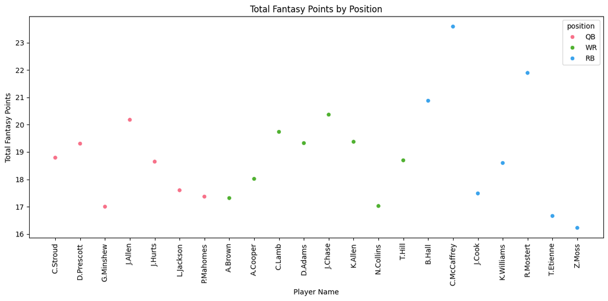

```python
# Define multipliers for fantasy points
multipliers = {
    'QB': {'passing_yards': 0.04, 'passing_tds': 4, 'rushing_yards': 0.1, 'rushing_tds': 6},
    'WR': {'receiving_yards': 0.1, 'receiving_tds': 6, 'receptions': 1},
    'RB': {'rushing_yards': 0.1, 'rushing_tds': 6, 'receiving_yards': 0.1, 'receiving_tds': 6, 'receptions': 1}
}

# Read QB data
df_qb = pd.read_csv("mean_predicted_QB_stats.csv")
df_qb['position'] = 'QB'
df_qb['total_fantasy_points'] = (df_qb['predicted_passing_yards'] * multipliers['QB']['passing_yards'] +
                                  df_qb['predicted_passing_tds'] * multipliers['QB']['passing_tds'] +
                                  df_qb['predicted_rushing_tds'] * multipliers['QB']['rushing_tds'] +
                                  df_qb['predicted_rushing_yards'] * multipliers['QB']['rushing_yards'])

# Read WR data
df_wr = pd.read_csv("mean_predicted_WR_stats.csv")
df_wr['position'] = 'WR'
df_wr['total_fantasy_points'] = (df_wr['predicted_receiving_yards'] * multipliers['WR']['receiving_yards'] +
                                  df_wr['predicted_receiving_tds'] * multipliers['WR']['receiving_tds'] +
                                  df_wr['predicted_receptions'] * multipliers['WR']['receptions'])

# Read RB data
df_rb = pd.read_csv("mean_predicted_RB_stats.csv")
df_rb['position'] = 'RB'
df_rb['total_fantasy_points'] = (df_rb['predicted_rushing_yards'] * multipliers['RB']['rushing_yards'] +
                                 df_rb['predicted_rushing_tds'] * multipliers['RB']['rushing_tds'] +
                                 df_rb['predicted_receiving_yards'] * multipliers['RB']['receiving_yards'] +
                                 df_rb['predicted_receiving_tds'] * multipliers['RB']['receiving_tds'] +
                                 df_rb['predicted_receptions'] * multipliers['RB']['receptions'])

# Merge all dataframes
df_all = pd.concat([df_qb, df_wr, df_rb])

# Filter out players with total fantasy points less than or equal to 16
df_all = df_all[df_all['total_fantasy_points'] > 16]

# Get unique positions
unique_positions = df_all['position'].unique()

# Create palette based on unique positions
palette = sns.color_palette("husl", len(unique_positions))

# Plot scatter plot for all positions using Seaborn
plt.figure(figsize=(12, 6))
sns.scatterplot(data=df_all, x='player_name', y='total_fantasy_points', hue='position', palette=palette, marker='o')
plt.title('Total Fantasy Points by Position')
plt.xlabel('Player Name')
plt.ylabel('Total Fantasy Points')
plt.xticks(rotation=90, ha='center')
plt.tight_layout()
plt.show()
```

### Question 4 Conclusion:

From this scatter plot based on the values calculated in the simulator, we can determine the best players to target in a Fantasy Football draft. The players plotted are the best at their positions but the situations they are in should be reviewed more thoroughly.

# Conclusion:

Overall this project gives a lot of good insight on the stats of football players from the 2023 season. There are some major flaws in the determination of a prediction for next year. One major flaw is only taking statistics from one year. With more data on each player, we can better determine how and where they will place in a prediction for next season.

### Things to improve:

- Base the simulator on efficiency ratings and not mean stats.
- Incorporate trades, free agency pickups, and rookies.
- Run the simulator 1000x with more precise defensive ratings, and more accurate team dynamics (ex. LA Chargers' lack of receivers could cause worse play out of Justin Herbert, But a more accurate simulation could take in the offensive line additions that would give him more time in the pocket to make better decisions or formulate a run game with Gus Edwards.)
- Stats can only determine a certain amount of how a player plays. An overall grade could help with a down year for a player(ex. Patrick Mahomes arguably had the worst season of his career despite winning the Superbowl)
- For more accurate fantasy rankings, take data from past years' drafts and plot correlations for certain players or positions on where they were drafted.